# GLM

Javier Colás Romanos

07/03/2021

El objetivo de este caso de estudio es predecir el número de casos que hubo en la primera ola del Covid-19, con datos de la segunda y tercera ola (más fiables). Utilizaremos un dataset realizado por Datadista (https://github.com/datadista/datasets/tree/master/COVID%2019). Para la predicción y la explicación de que causa los casos de Covid-19, utilizaremos las variables que a priori tienen más sentido para mi (ccaa, sexo, grupo_Edad, num_hosp, num_uci, num_Def), además de éstas variables introduciremos la densidad de población. Aunque realmente es imposible saber cuales son ( la diferencia entre correlación y causalidad forma el sesgo). Para ello utilizaremos modelos GLM, tratando de relajar las hipótesis de las regresiones múltiples.

```r
library(tidyverse)
library(ggplot2)
library(naniar)
library(mice)
library(VIM)
library(effects)
library(reshape2)
library(pscl)
```

### Preparación de datos.

```r
load("casos.RData")
str(casos)
```

```
## 'data.frame':    655080 obs. of  11 variables:
##  $ provincia_iso: Factor w/ 53 levels "A","AB","AL",..: 1 1 1 1 1 1 1 1 1 1 ...
##  $ sexo         : Factor w/ 3 levels "Hombres","Mujeres",..: 1 1 1 1 1 1 1 1 1 1 ...
##  $ grupo_edad   : Factor w/ 10 levels "0-9","10-19",..: 1 2 3 4 5 6 7 8 9 10 ...
##  $ fecha        : Date, format: "2020-01-01" "2020-01-01" ...
##  $ num_casos    : int  0 0 0 0 0 0 0 0 0 0 ...
##  $ num_hosp     : int  0 0 0 0 0 0 0 0 0 0 ...
##  $ num_uci      : int  0 0 0 0 0 0 0 0 0 0 ...
##  $ num_def      : int  0 0 0 0 0 0 0 0 0 0 ...
##  $ provincia    : Factor w/ 53 levels "Almería","Cádiz",..: 35 35 35 35 35 35 35 35 35 35 ...
##  $ iso          : Factor w/ 19 levels "AN","AR","AS",..: 10 10 10 10 10 10 10 10 10 10 ...
##  $ ccaa         : Factor w/ 20 levels "Andalucía","Aragón",..: 10 10 10 10 10 10 10 10 10 10 ...
##  - attr(*, "url")= chr "https://cnecovid.isciii.es/covid19/resources/casos_hosp_uci_def_sexo_edad_provres.csv.csv"
```

```r
summary(casos)
```

```
##  provincia_iso         sexo          grupo_edad         fecha
##  A      : 12360   Hombres:218360   0-9    : 65508   Min.   :2020-01-01
##  AB     : 12360   Mujeres:218360   10-19  : 65508   1st Qu.:2020-04-12
##  AL     : 12360   NA     :218360   20-29  : 65508   Median :2020-07-24
##  AV     : 12360                    30-39  : 65508   Mean   :2020-07-24
##  B      : 12360                    40-49  : 65508   3rd Qu.:2020-11-04
##  BA     : 12360                    50-59  : 65508   Max.   :2021-02-15
##  (Other):580920                    (Other):262032
##    num_casos          num_hosp           num_uci            num_def
##  Min.   :  0.000   Min.   :  0.0000   Min.   : 0.00000   Min.   :  0.00000
##  1st Qu.:  0.000   1st Qu.:  0.0000   1st Qu.: 0.00000   1st Qu.:  0.00000
##  Median :  0.000   Median :  0.0000   Median : 0.00000   Median :  0.00000
##  Mean   :  4.711   Mean   :  0.4625   Mean   : 0.03996   Mean   :  0.09991
##  3rd Qu.:  2.000   3rd Qu.:  0.0000   3rd Qu.: 0.00000   3rd Qu.:  0.00000
##  Max.   :764.000   Max.   :269.0000   Max.   :35.00000   Max.   :100.00000
##
##    provincia           iso                         ccaa
##  Almería: 12360   CL     :111240   Castilla y León   :111240
##  Cádiz  : 12360   AN     : 98880   Andalucía         : 98880
##  Córdoba: 12360   CM     : 61800   Castilla-La Mancha: 61800
##  Granada: 12360   CT     : 49440   Cataluña          : 49440
##  Huelva : 12360   GA     : 49440   Galicia           : 49440
##  Jaén   : 12360   (Other):271920   Aragón            : 37080
##  (Other):580920   NA's   : 12360   (Other)           :247200
```

En la varaible “sexo” hay una categoria NA, aunque realmente no computan como tal. Así que los convertimos a verdaderos nulos.

```r
imputacion_na = function(x){
  ifelse(x == "NA", NaN, as.character(x))
}
casos$sexo = sapply(casos$sexo, imputacion_na)
```

Por otra parte, la fecha de inicio del dataset es el 2020-01-01. Solo nos interesa desde el inicio del mes de Marzo.

```r
fecha_inicio_covid = as.Date("2020-03-01")

casos = casos[casos$fecha > fecha_inicio_covid, ]
```

Quiero ver como se comportan los valores nulos de la variable sexo frete a la fecha, es decir, si estos nulos se encuentran al principio de la pandemia (por falta de medios) o se distribuyen por toda la serie temporal.

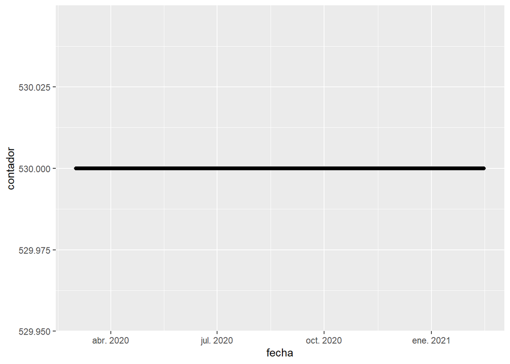

```r
na_Sexo_fecha = as.data.frame(select(casos, sexo, fecha) %>%
  group_by(fecha, sexo) %>%
  summarize(contador = n()))


na_Sexo_fecha = na_Sexo_fecha[na_Sexo_fecha$sexo == NaN,]

ggplot(na_Sexo_fecha, aes(x = fecha, y = contador))+
  geom_point()
```

Llama mucho la atención que el número de valores nulos en la varaible sexo, a lo largo de toda la pandamia sea constante. No he encontrado una expliación coherente para esto. Además el número de hombres y mujeres es el mismo. Puede ser que las conclusiones futuras estén sesgadas por esta variable.

```r
table(casos$sexo)
```

```
##
## Hombres Mujeres
##  186030  186030
```

Eliminamos los valores nulos, ya que no siguen ningún patron, ni tiene sentido hacer imputaciones.

```r
casos = na.omit(object = casos)
casos = casos[casos$sexo != "NaN",]
casos = casos[casos$grupo_edad != "NC",]
```

Una vez tenemos el Dataset limpio, nos guardamos una copia como “casos_comparacion” , que usaremos para comparar la predicción con los casos contabilizados en la primera ola.

```r
casos_comparacion = data.frame(casos)
```

```r
dim(casos)
```

```
## [1] 328536     11
```

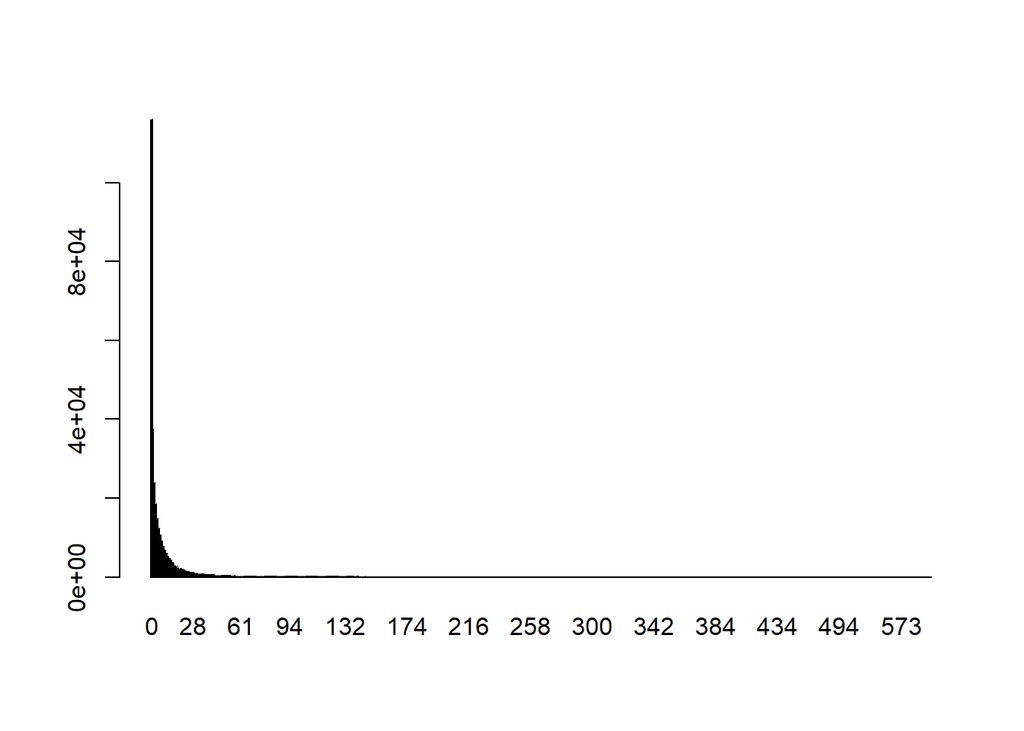

```r
barplot(table(casos$num_casos))
```

### desarrollo e interpretación de modelos

El Dataset con el que trabajaremos tiene unas dimensiones de 11 variables y 328.536 observaciones. La distribución de nuestra variable Target (num_Casos) claramente es una distribución no normal, la naturaleza de la variable target (su predicción) se asemeja a una Poisson, función de probabilidad discreta, que expresa a partir de una ocurrencia media la probabilidad de que ocurra un determinado numero de eventos durante cierto perido de tiempo. Además es una Poisson con cero inflado, ya que en muchas observaciones el número de casos es 0. Resulta extraño que durante toda la pandemia, la mayoría de observaciones sea 0, (todos los días hay casos), la explicación es porque contiene mucha información en detalle (sexo, grupo_Edad, CCAA, provincia,…) y los datos en la primera ola no están contabilizados.

(Gráfico sin suavizar, simplemente para mostrar la afirmación anterior)

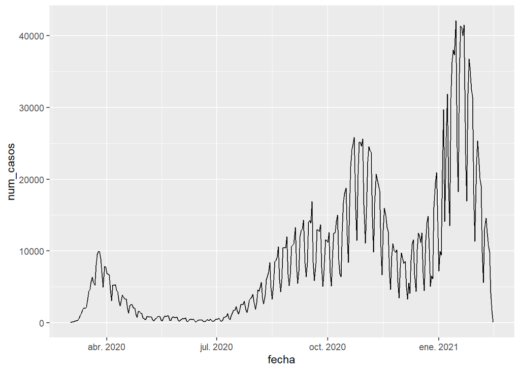

```r
numero_casos = casos %>%
  group_by(fecha) %>%
    summarize(num_casos = sum(num_casos))

ggplot(numero_casos, aes(x = fecha, y = num_casos)) +
  geom_line()
```

```r
fecha_final_covid = as.Date("2021-02-01")
casos = casos[casos$fecha < fecha_final_covid,]
```

Hacemos el mismo gráfico anterior con la fecha acotada.

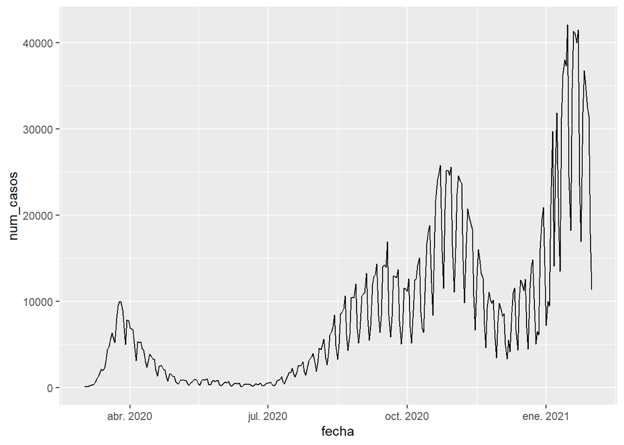

```r
numero_casos = casos %>%
  group_by(fecha) %>%
  summarize(num_casos = sum(num_casos))

ggplot(numero_casos, aes(x = fecha, y = num_casos)) +
  geom_line()
```

¿ Hay más número de positivos de sexo masculino o femenino?

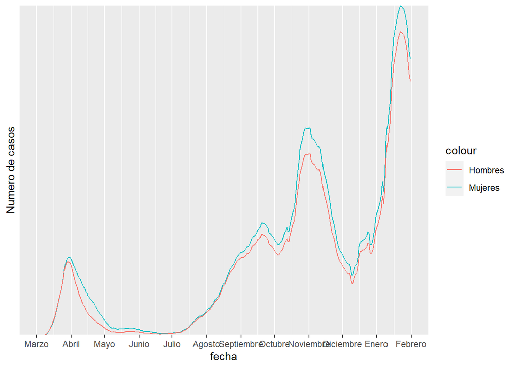

```r
casos_hombres = casos %>%
  filter(sexo == "Hombres") %>%
  group_by(fecha) %>%
    summarize(num_casos = sum(num_casos))

casos_mujeres = casos %>%
  filter(sexo == "Mujeres") %>%
  group_by(fecha) %>%
  summarize(num_casos = sum(num_casos))

#Suavizamos los datos, con media movil de 7 días.

#Hombres
for ( i in 8:nrow(casos_hombres)){
  casos_hombres[i, "ean7_num_cases_hombres"] = sum(casos_hombres[(i-7):(i-1),"num_casos"])/7
}
#Mujeres
for ( i in 8:nrow(casos_mujeres)){
  casos_mujeres[i, "ean7_num_cases_mujeres"] = sum(casos_mujeres[(i-7):(i-1),"num_casos"])/7}

  casos_sexo_grafico = merge(casos_hombres, casos_mujeres, by = "fecha")

  ggplot(casos_sexo_grafico, aes(x = fecha)) +
  geom_line(aes(y = ean7_num_cases_mujeres, colour = "Mujeres")) +
  geom_line(aes(y = ean7_num_cases_hombres, colour = "Hombres"))+
  scale_y_discrete("Numero de casos") +
  scale_x_continuous(breaks  = c(as.Date("2020-03-01"), as.Date("2020-04-01"), as.Date("2020-05-01"),
                                 as.Date("2020-06-01"), as.Date("2020-07-01"), as.Date("2020-08-01"),
                                 as.Date("2020-09-01"), as.Date("2020-10-01"), as.Date("2020-11-01"),
                                 as.Date("2020-12-01"), as.Date("2021-01-01"), as.Date("2021-02-01")),
                     labels = c("Marzo", "Abril", "Mayo", "Junio", "Julio", "Agosto", "Septiembre", "Octubre",
                                "Noviembre", "Diciembre", "Enero", "Febrero"))
```

El número de casos positivos en Hombres es inferior en la mayor parte de la pandemia frete al de las mujeres. Las mujeres se contagian más. ¿ Y el número de muertes por sexo se comporta de las misma forma?

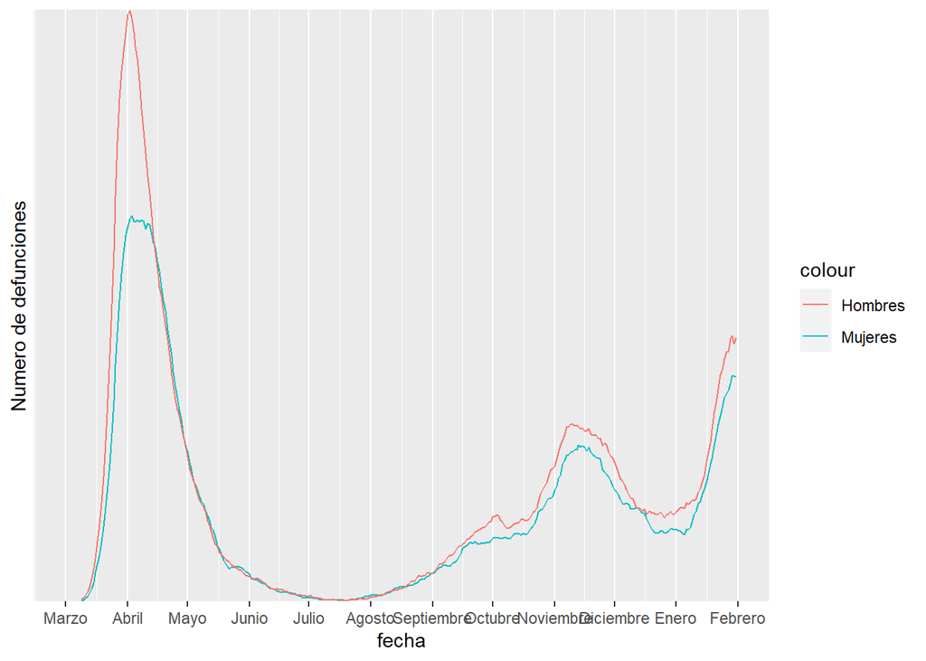

```r
def_hombres = casos %>%
  filter(sexo == "Hombres") %>%
  group_by(fecha) %>%
  summarize(num_def = sum(num_def))

def_mujeres = casos %>%
  filter(sexo == "Mujeres") %>%
  group_by(fecha) %>%
  summarize(num_def = sum(num_def))

#Suavizamos los datos, con media movil de 7 días.

#Hombres
for ( i in 8:nrow(def_hombres)){
  def_hombres[i, "ean7_num_def_hombres"] = sum(def_hombres[(i-7):(i-1),"num_def"])/7
}
#Mujeres
for ( i in 8:nrow(casos_mujeres)){
  def_mujeres[i, "ean7_num_def_mujeres"] = sum(def_mujeres[(i-7):(i-1),"num_def"])/7}

def_sexo_grafico = merge(def_hombres, def_mujeres, by = "fecha")

ggplot(def_sexo_grafico, aes(x = fecha)) +
    geom_line(aes(y = ean7_num_def_mujeres, colour = "Mujeres")) +
    geom_line(aes(y = ean7_num_def_hombres, colour = "Hombres"))+
    scale_y_discrete("Numero de defunciones") +
    scale_x_continuous(breaks  = c(as.Date("2020-03-01"), as.Date("2020-04-01"), as.Date("2020-05-01"),
                                 as.Date("2020-06-01"), as.Date("2020-07-01"), as.Date("2020-08-01"),
                                 as.Date("2020-09-01"), as.Date("2020-10-01"), as.Date("2020-11-01"),
                                 as.Date("2020-12-01"), as.Date("2021-01-01"), as.Date("2021-02-01")),
                     labels = c("Marzo", "Abril", "Mayo", "Junio", "Julio", "Agosto", "Septiembre", "Octubre",
                                "Noviembre", "Diciembre", "Enero", "Febrero"))
```

A diferencia de el número de casos, los hombres mueren más, es decir, tienen una tasa de letalidad mayor. Especialmente en la primera ola, aunque inferir con datos de la primera ola no es muy significativo. ¿ Y como se relaciona el número de casos positivos con los grupos de edad?

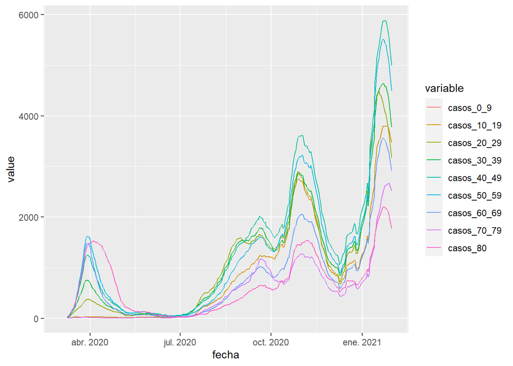

```r
casos_0_9 = as.data.frame(casos %>%
  filter(grupo_edad == "0-9") %>%
  group_by(fecha) %>%
  summarize(num_casos = sum(num_casos)))

casos_10_19 = as.data.frame(casos %>%
  filter(grupo_edad == "10-19") %>%
  group_by(fecha) %>%
  summarize(num_casos = sum(num_casos)))

casos_20_29 = as.data.frame(casos %>%
  filter(grupo_edad == "20-29") %>%
  group_by(fecha) %>%
  summarize(num_casos = sum(num_casos)))

casos_30_39 = as.data.frame(casos %>%
  filter(grupo_edad == "30-39") %>%
  group_by(fecha) %>%
  summarize(num_casos = sum(num_casos)))

casos_40_49 = as.data.frame(casos %>%
  filter(grupo_edad == "40-49") %>%
  group_by(fecha) %>%
  summarize(num_casos = sum(num_casos)))

casos_50_59 = as.data.frame(casos %>%
  filter(grupo_edad == "50-59") %>%
  group_by(fecha) %>%
  summarize(num_casos = sum(num_casos)))

casos_60_69 = as.data.frame(casos %>%
  filter(grupo_edad == "60-69") %>%
  group_by(fecha) %>%
  summarize(num_casos = sum(num_casos)))

casos_70_79 = as.data.frame(casos %>%
  filter(grupo_edad == "0-9") %>%
  group_by(fecha) %>%
  summarize(num_casos = sum(num_casos)))
casos_80 = as.data.frame(casos %>%
  filter(grupo_edad == "80+") %>%
  group_by(fecha) %>%
  summarize(num_casos = sum(num_casos)))

#Suavizamos los datos, con media movil de 7 días.

suavizar <- function(dataset, nombre_columna){
  for ( i in 8:nrow(dataset)){
    dataset[i, nombre_columna] <- sum(dataset[(i-7):(i-1),"num_casos"])/7}
    return(dataset)
  }

casos_0_9=suavizar(casos_0_9,"casos_0_9")
casos_10_19=suavizar(casos_10_19,"casos_10_19")
casos_20_29=suavizar(casos_20_29,"casos_20_29")
casos_30_39=suavizar(casos_30_39,"casos_30_39")
casos_40_49=suavizar(casos_40_49,"casos_40_49")
casos_50_59=suavizar(casos_50_59,"casos_50_59")
casos_60_69=suavizar(casos_60_69,"casos_60_69")
casos_70_79=suavizar(casos_70_79,"casos_70_79")
casos_80=suavizar(casos_80,"casos_80")

ccaa_dataframe = cbind(casos_0_9, casos_10_19, casos_20_29, casos_30_39,casos_40_49, casos_50_59, casos_60_69, casos_70_79, casos_80  )

ccaa_dataframe = ccaa_dataframe[, c(1,3,6,9,12,15,18,21,24,27)]


ccaa_dataframe = melt(ccaa_dataframe, id.vars = c("fecha"))

ggplot(ccaa_dataframe, aes(fecha, y = value, colour = variable)) +
  geom_line()
```

Las personas en grupos de edad extremas son las que menos se contagian, y las que más las personas en rango de edad intermedio.

Para demostrar que realmente los datos tomados por esta fuente en el número de casos positivos en la primera ola es incorrecto, vamos a representar las defunciones y los casos positivos, así como la tasa de letalidad.

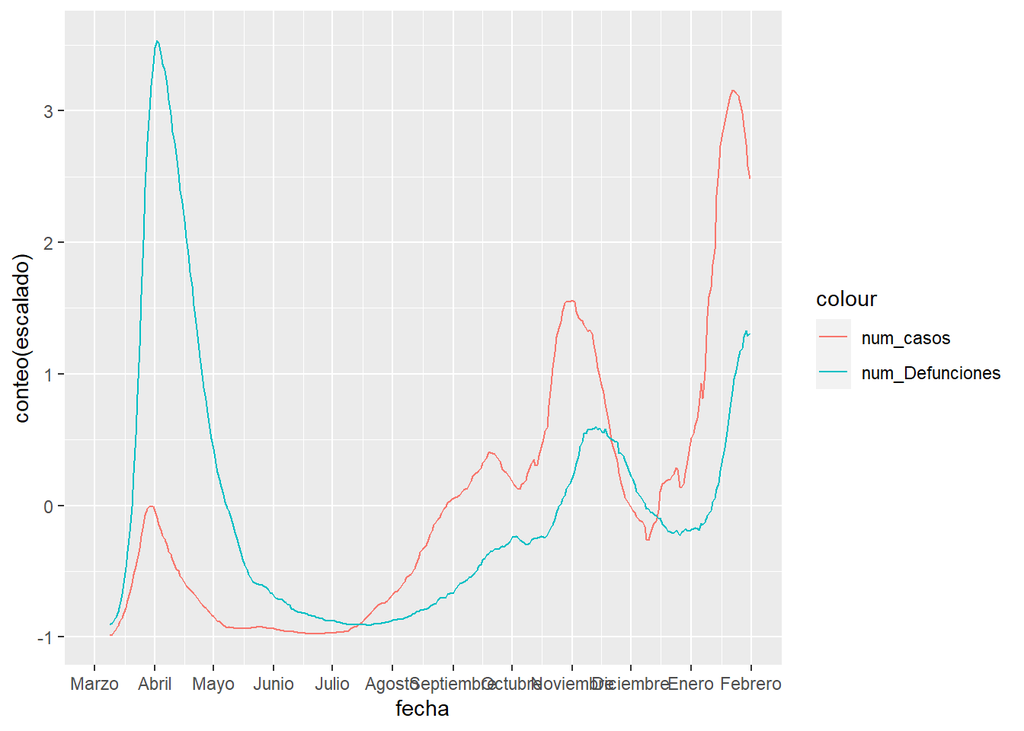

```r
casos_positivos_muertes = casos %>%
  group_by(fecha ) %>%
    summarize(num_casos = sum(num_casos), num_def = sum(num_def))

# Estandarizamos los datos para poder compararlos en una misma gráfica.

casos_positivos_muertes$num_casos = scale(casos_positivos_muertes$num_casos)
casos_positivos_muertes$num_def = scale(casos_positivos_muertes$num_def)


numero_casos_fecha = casos %>%
  group_by(fecha) %>%
  summarize(numero_casos = sum(num_casos))

numero_defunciones = casos %>%
  group_by(fecha) %>%
  summarize(num_def = sum(num_def))

for ( i in 8:nrow(numero_casos_fecha)){
  numero_casos_fecha[i, "ean7_num_cases"] = sum(numero_casos_fecha[(i-7):(i-1),"numero_casos"])/7
}

# Escalamos la columna

numero_casos_fecha$ean7_num_cases = scale(numero_casos_fecha$ean7_num_cases)
casos_positivos_muertes$num_casos = numero_casos_fecha$ean7_num_cases

# Hacemos lo mismo para las muertes.

numero_defunciones$media_num_def = 1
for ( i in 8:nrow(numero_defunciones)){
  numero_defunciones[i, "media_num_def"] = sum(numero_defunciones[(i-7):(i-1),"num_def"])/7
}

numero_defunciones[1:7,"media_num_def" ] = NA

casos_positivos_muertes$num_def = scale(numero_defunciones$media_num_def)

ggplot(casos_positivos_muertes, aes(x = fecha)) +
  geom_line(aes(y = num_casos, colour = "num_casos")) +
  geom_line(aes(y = num_def, colour = "num_Defunciones")) +
  scale_x_continuous(breaks  = c(as.Date("2020-03-01"), as.Date("2020-04-01"), as.Date("2020-05-01"),
                                 as.Date("2020-06-01"), as.Date("2020-07-01"), as.Date("2020-08-01"),
                                 as.Date("2020-09-01"), as.Date("2020-10-01"), as.Date("2020-11-01"),
                                 as.Date("2020-12-01"), as.Date("2021-01-01"), as.Date("2021-02-01")),
                     labels = c("Marzo", "Abril", "Mayo", "Junio", "Julio", "Agosto", "Septiembre", "Octubre",
                                "Noviembre", "Diciembre", "Enero", "Febrero")) +
  labs(x = "fecha",y = "conteo(escalado)")
```

El número de muertes en la primera ola es muy superior al número de casos, algo que no tiene sentido.

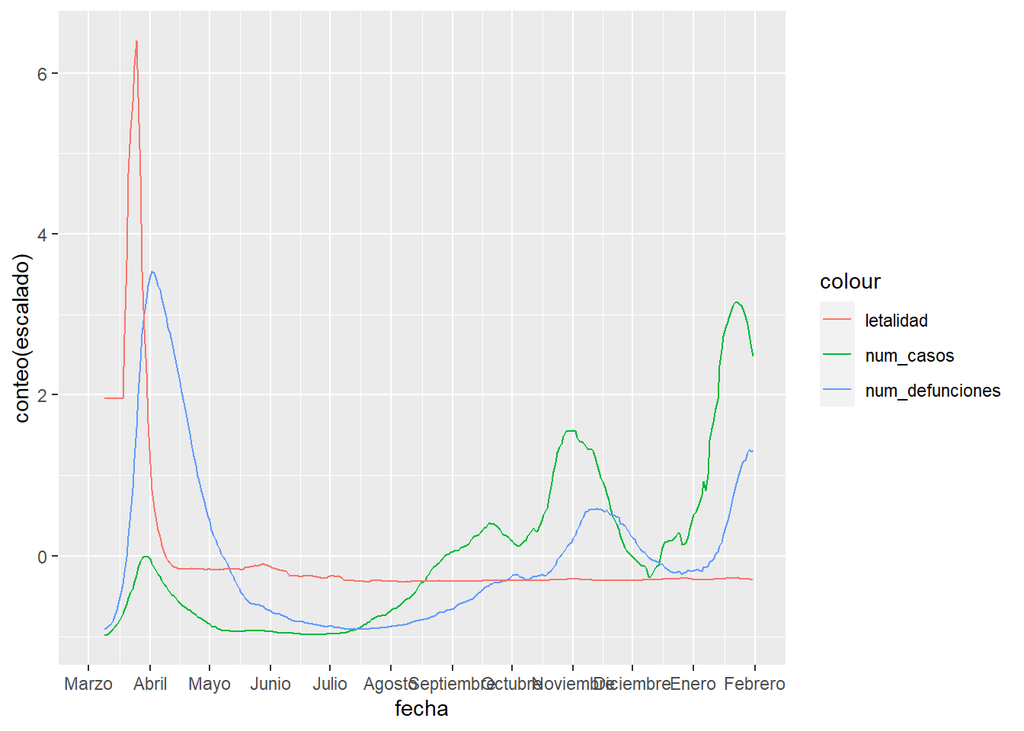

```r
letalidad = casos %>%
  group_by(fecha) %>%
  summarize(num_def = sum(num_def), num_casos = sum(num_casos))

letalidad$i.letalidad = 1
for ( i in 17:nrow(letalidad)){
  letalidad[i, "i.letalidad"] = (letalidad[i,"num_def"])/((letalidad[i-16,"num_casos"]))
}
#Suavizamos la letalidad
for ( i in 8:nrow(casos_positivos_muertes)){
  casos_positivos_muertes[i, "letalidad"] = sum(letalidad[(i-7):(i-1),"i.letalidad"])/7
}

casos_positivos_muertes$letalidad = scale(casos_positivos_muertes$letalidad)
# Los prmieros datos no tienes sentido

ggplot(casos_positivos_muertes, aes(x = fecha)) +
  geom_line(aes(y = num_casos, colour= "num_casos")) +
  geom_line(aes(y = num_def, colour = "num_defunciones")) +
  geom_line(aes(y = letalidad, colour = "letalidad")) +
  scale_x_continuous(breaks  = c(as.Date("2020-03-01"), as.Date("2020-04-01"), as.Date("2020-05-01"),
                                 as.Date("2020-06-01"), as.Date("2020-07-01"), as.Date("2020-08-01"),
                                 as.Date("2020-09-01"), as.Date("2020-10-01"), as.Date("2020-11-01"),
                                 as.Date("2020-12-01"), as.Date("2021-01-01"), as.Date("2021-02-01")),
                     labels = c("Marzo", "Abril", "Mayo", "Junio", "Julio", "Agosto", "Septiembre", "Octubre",
                                "Noviembre", "Diciembre", "Enero", "Febrero"))+
  labs(x = "fecha",y = "conteo(escalado)")
```

Lo primero que vamos a hacer es separar los datos entre Train ( después del 1 de Julio de 2020) y Test (desde 1 de Marzo hasta el 1 de Julio de 2020). Además vamos a introducir una nueva variable para enriquecer los datos, la densidad de población de cada CCAA.

```r
casos_test = casos[casos$fecha < as.Date("2020-07-01"),]
casos = casos[casos$fecha > as.Date("2020-07-01"),]

densidad_poblacion = read.csv("densidad_ccaa.csv", header = TRUE, sep = ";", encoding = "UTF-8", stringsAsFactors = FALSE)
casos = merge( casos, densidad_poblacion, by.x = "ccaa" , by.y = "X.U.FEFF.Nombre")
casos_test = merge( casos_test, densidad_poblacion, by.x = "ccaa" , by.y = "X.U.FEFF.Nombre")
names(casos_test)[names(casos_test) == "Densidad..hab..km²."] <- "densidad"
```

Quitamos las columnas de los dataset que no nos interesan. Y limpiamos la nueva variable densidad.

```r
casos_test$provincia_iso = NULL
casos_test$iso = NULL
casos_test$provincia = NULL

casos$provincia_iso = NULL
casos$iso = NULL
casos$provincia = NULL

limpieza = function(i){
  i = str_replace(i, ",", ".")
  i = as.numeric(i)
}


casos_test$densidad = sapply(casos_test$densidad , limpieza)
casos$`Densidad..hab..km².` = sapply(casos$`Densidad..hab..km².`, limpieza)

str(casos)
```

```
## 'data.frame':    200304 obs. of  9 variables:
##  $ ccaa               : Factor w/ 20 levels "Andalucía","Aragón",..: 1 1 1 1 1 1 1 1 1 1 ...
##  $ sexo               : chr  "Mujeres" "Mujeres" "Hombres" "Hombres" ...
##  $ grupo_edad         : Factor w/ 10 levels "0-9","10-19",..: 1 3 2 4 7 7 4 8 8 3 ...
##  $ fecha              : Date, format: "2020-11-05" "2020-11-30" ...
##  $ num_casos          : int  6 6 8 0 7 0 0 1 3 0 ...
##  $ num_hosp           : int  0 0 0 0 2 0 0 2 0 0 ...
##  $ num_uci            : int  0 0 0 0 0 0 0 0 0 0 ...
##  $ num_def            : int  0 0 0 0 0 0 0 2 0 0 ...
##  $ Densidad..hab..km².: num  96.6 96.6 96.6 96.6 96.6 ...
```

Vamos a hacer unas pequeñas correcciones del dataset, para que las predicciones sean mas certeras. Vamos a trasladar el número de fallecidos de t a t+17 (dependiendo de la fuente, se estima que un positivo si fallece tarda en hacerlo entre 2 y 4 semanas (aunque los grupos de riesgo lo hacen antes), los hospitalizados a t+10 y uci a t+12. Trabajaremos sobre una copia del dataframe sin la fecha.

```r
casos_sin_fecha = casos
casos_sin_fecha$fecha = NULL

#Trasformaciones

#def
for ( i in 1:nrow(casos_sin_fecha)){
  casos_sin_fecha[i + 17, "muertes_17"] = casos_sin_fecha[i, "num_def"]
}

# hosp
for ( i in 1:nrow(casos_sin_fecha)){
  casos_sin_fecha[i + 10, "hosp_10"] = casos_sin_fecha[i, "num_hosp"]
}

#uci
for ( i in 1:nrow(casos_sin_fecha)){
  casos_sin_fecha[i + 12, "uci_12"] = casos_sin_fecha[i, "num_uci"]
}


# Eliminamos las columnas num_def, num_uci, num_hosp.

casos_sin_fecha$num_def = NULL
casos_sin_fecha$num_hosp = NULL
casos_sin_fecha$num_uci = NULL
names(casos_sin_fecha)[names(casos_sin_fecha) == "Densidad..hab..km²."] <- "densidad"
```

Creamos nuestro modelo de regresión lineal. Servirá como referencia para decidir si nuestro modelo GLM predice peor o mejor que un modelo más básico.

```r
fit.lm <- lm(num_casos ~ . , data=casos_sin_fecha)
summary(fit.lm)
```

```
##
## Call:
## lm(formula = num_casos ~ ., data = casos_sin_fecha)
##
## Residuals:
##     Min      1Q  Median      3Q     Max
## -156.82   -8.34   -2.41    3.35  651.43
##
## Coefficients: (1 not defined because of singularities)
##                           Estimate Std. Error t value Pr(>|t|)
## (Intercept)                6.21628    0.24325  25.555  < 2e-16 ***
## ccaaAragón                -5.35389    0.29936 -17.885  < 2e-16 ***
## ccaaAsturias              -4.57933    0.46921  -9.760  < 2e-16 ***
## ccaaCanarias              -8.26002    0.34984 -23.611  < 2e-16 ***
## ccaaCantabria             -7.34974    0.46906 -15.669  < 2e-16 ***
## ccaaCastilla y León       -7.74593    0.21528 -35.980  < 2e-16 ***
## ccaaCastilla-La Mancha    -5.20098    0.25248 -20.599  < 2e-16 ***
## ccaaCataluña              16.65132    0.27082  61.485  < 2e-16 ***
## ccaaCeuta                -11.46801    0.46962 -24.420  < 2e-16 ***
## ccaaComunidad Valenciana  13.85069    0.30079  46.047  < 2e-16 ***
## ccaaExtremadura           -4.62680    0.34966 -13.232  < 2e-16 ***
## ccaaGalicia               -6.84650    0.27097 -25.267  < 2e-16 ***
## ccaaIslas Baleares         0.12630    0.46900   0.269 0.787706
## ccaaLa Rioja              -6.92988    0.46905 -14.774  < 2e-16 ***
## ccaaMadrid                92.10351    0.54597 168.696  < 2e-16 ***
## ccaaMelilla              -10.55252    0.46942 -22.480  < 2e-16 ***
## ccaaMurcia                10.71150    0.47026  22.778  < 2e-16 ***
## ccaaNavarra               -1.68194    0.46894  -3.587 0.000335 ***
## ccaaPaís Vasco            -2.08091    0.29942  -6.950 3.67e-12 ***
## sexoMujeres                1.44911    0.12264  11.816  < 2e-16 ***
## grupo_edad10-19            5.28371    0.26014  20.311  < 2e-16 ***
## grupo_edad20-29            8.19986    0.26015  31.519  < 2e-16 ***
## grupo_edad30-39            8.61429    0.26017  33.110  < 2e-16 ***
## grupo_edad40-49           11.87114    0.26016  45.630  < 2e-16 ***
## grupo_edad50-59            9.39762    0.26016  36.123  < 2e-16 ***
## grupo_edad60-69            2.90454    0.26016  11.165  < 2e-16 ***
## grupo_edad70-79           -1.17168    0.26014  -4.504 6.67e-06 ***
## grupo_edad80+             -0.65576    0.26013  -2.521 0.011706 *
## densidad                        NA         NA      NA       NA
## muertes_17                 0.71635    0.08050   8.898  < 2e-16 ***
## hosp_10                    0.93411    0.02528  36.944  < 2e-16 ***
## uci_12                     3.18887    0.17288  18.446  < 2e-16 ***
## ---
## Signif. codes:  0 '***' 0.001 '**' 0.01 '*' 0.05 '.' 0.1 ' ' 1
##
## Residual standard error: 27.44 on 200256 degrees of freedom
##   (56 observations deleted due to missingness)
## Multiple R-squared:  0.2914, Adjusted R-squared:  0.2913
## F-statistic:  2745 on 30 and 200256 DF,  p-value: < 2.2e-16
```

La CCAA que más casos positivos aporta es Madrid; el grupo de edad más contagiosos está entre 40 y 49 años, y los ingresados en uci a 12 días es un mejor reflejo del número de positivos que los fallecidos y los hospitalizados.

Modelo GLM con todos los predictores posibles.

```r
fit.poisson <- glm(num_casos ~ . , family = "poisson", data = casos_sin_fecha)
summary(fit.poisson)
```

```
##
## Call:
## glm(formula = num_casos ~ ., family = "poisson", data = casos_sin_fecha)
##
## Deviance Residuals:
##     Min       1Q   Median       3Q      Max
## -22.472   -2.999   -1.330    0.808   44.409
##
## Coefficients: (1 not defined because of singularities)
##                            Estimate Std. Error  z value Pr(>|z|)
## (Intercept)               2.0193682  0.0028425  710.408   <2e-16 ***
## ccaaAragón               -0.5507972  0.0037521 -146.796   <2e-16 ***
## ccaaAsturias             -0.3733723  0.0055897  -66.796   <2e-16 ***
## ccaaCanarias             -1.1244786  0.0057896 -194.224   <2e-16 ***
## ccaaCantabria            -0.8984533  0.0072076 -124.654   <2e-16 ***
## ccaaCastilla y León      -1.0107195  0.0029421 -343.539   <2e-16 ***
## ccaaCastilla-La Mancha   -0.5851396  0.0031227 -187.382   <2e-16 ***
## ccaaCataluña              0.8277324  0.0021607  383.078   <2e-16 ***
## ccaaCeuta                -3.3441102  0.0240599 -138.991   <2e-16 ***
## ccaaComunidad Valenciana  0.7526314  0.0023637  318.415   <2e-16 ***
## ccaaExtremadura          -0.4850694  0.0043391 -111.790   <2e-16 ***
## ccaaGalicia              -0.8097524  0.0037138 -218.036   <2e-16 ***
## ccaaIslas Baleares        0.0112990  0.0047164    2.396   0.0166 *
## ccaaLa Rioja             -0.8230520  0.0069475 -118.468   <2e-16 ***
## ccaaMadrid                1.9803699  0.0025949  763.167   <2e-16 ***
## ccaaMelilla              -2.1128429  0.0130409 -162.017   <2e-16 ***
## ccaaMurcia                0.6358993  0.0035804  177.607   <2e-16 ***
## ccaaNavarra              -0.1486845  0.0050709  -29.321   <2e-16 ***
## ccaaPaís Vasco           -0.2008964  0.0032677  -61.480   <2e-16 ***
## sexoMujeres               0.1104220  0.0012415   88.943   <2e-16 ***
## grupo_edad10-19           0.4981104  0.0029778  167.277   <2e-16 ***
## grupo_edad20-29           0.6863180  0.0028757  238.658   <2e-16 ***
## grupo_edad30-39           0.7159128  0.0028651  249.874   <2e-16 ***
## grupo_edad40-49           0.8941280  0.0027860  320.935   <2e-16 ***
## grupo_edad50-59           0.7637351  0.0028416  268.767   <2e-16 ***
## grupo_edad60-69           0.2985168  0.0030973   96.380   <2e-16 ***
## grupo_edad70-79          -0.1536542  0.0034522  -44.509   <2e-16 ***
## grupo_edad80+            -0.0818827  0.0033817  -24.214   <2e-16 ***
## densidad                         NA         NA       NA       NA
## muertes_17                0.0150320  0.0004080   36.845   <2e-16 ***
## hosp_10                   0.0138272  0.0001036  133.523   <2e-16 ***
## uci_12                    0.0690073  0.0008558   80.639   <2e-16 ***
## ---
## Signif. codes:  0 '***' 0.001 '**' 0.01 '*' 0.05 '.' 0.1 ' ' 1
##
## (Dispersion parameter for poisson family taken to be 1)
##
##     Null deviance: 6025594  on 200286  degrees of freedom
## Residual deviance: 3348040  on 200256  degrees of freedom
##   (56 observations deleted due to missingness)
## AIC: 3960641
##
## Number of Fisher Scoring iterations: 6
```

Los resultados de la densidad de población son Nulos, porque los datos tienen muy poca variabilidad. Eliminamos la variable.

Todas las variables son siginificativas, aunque solo podemos afirmar eso en las variables categóricas. La interpretación de los “betas” será que al incrementar una unidad de los predictores, la variable dependiente aumenta exp(beta_i).

Para comparar modelos GLM no podemos usar la métrica R^2, sino que usamos la devianza, es decir, como de malo es un modelo. La Null Deviance muestra como de buena es la variable respuesta para un modelo que solo influye el intercepto, se asemeja a predecir con la media. Y la Residual Deviance corresponde al modelo entrenado. Nos fijaremos en como se comportan estas dos métricas entre ellas, para comparar los modelos.

```r
fit.poisson <- glm(num_casos ~ . -densidad, family = "poisson", data = casos_sin_fecha)
summary(fit.poisson)
```

```
##
## Call:
## glm(formula = num_casos ~ . - densidad, family = "poisson", data = casos_sin_fecha)
##
## Deviance Residuals:
##     Min       1Q   Median       3Q      Max
## -22.472   -2.999   -1.330    0.808   44.409
##
## Coefficients:
##                            Estimate Std. Error  z value Pr(>|z|)
## (Intercept)               2.0193682  0.0028425  710.408   <2e-16 ***
## ccaaAragón               -0.5507972  0.0037521 -146.796   <2e-16 ***
## ccaaAsturias             -0.3733723  0.0055897  -66.796   <2e-16 ***
## ccaaCanarias             -1.1244786  0.0057896 -194.224   <2e-16 ***
## ccaaCantabria            -0.8984533  0.0072076 -124.654   <2e-16 ***
## ccaaCastilla y León      -1.0107195  0.0029421 -343.539   <2e-16 ***
## ccaaCastilla-La Mancha   -0.5851396  0.0031227 -187.382   <2e-16 ***
## ccaaCataluña              0.8277324  0.0021607  383.078   <2e-16 ***
## ccaaCeuta                -3.3441102  0.0240599 -138.991   <2e-16 ***
## ccaaComunidad Valenciana  0.7526314  0.0023637  318.415   <2e-16 ***
## ccaaExtremadura          -0.4850694  0.0043391 -111.790   <2e-16 ***
## ccaaGalicia              -0.8097524  0.0037138 -218.036   <2e-16 ***
## ccaaIslas Baleares        0.0112990  0.0047164    2.396   0.0166 *
## ccaaLa Rioja             -0.8230520  0.0069475 -118.468   <2e-16 ***
## ccaaMadrid                1.9803699  0.0025949  763.167   <2e-16 ***
## ccaaMelilla              -2.1128429  0.0130409 -162.017   <2e-16 ***
## ccaaMurcia                0.6358993  0.0035804  177.607   <2e-16 ***
## ccaaNavarra              -0.1486845  0.0050709  -29.321   <2e-16 ***
## ccaaPaís Vasco           -0.2008964  0.0032677  -61.480   <2e-16 ***
## sexoMujeres               0.1104220  0.0012415   88.943   <2e-16 ***
## grupo_edad10-19           0.4981104  0.0029778  167.277   <2e-16 ***
## grupo_edad20-29           0.6863180  0.0028757  238.658   <2e-16 ***
## grupo_edad30-39           0.7159128  0.0028651  249.874   <2e-16 ***
## grupo_edad40-49           0.8941280  0.0027860  320.935   <2e-16 ***
## grupo_edad50-59           0.7637351  0.0028416  268.767   <2e-16 ***
## grupo_edad60-69           0.2985168  0.0030973   96.380   <2e-16 ***
## grupo_edad70-79          -0.1536542  0.0034522  -44.509   <2e-16 ***
## grupo_edad80+            -0.0818827  0.0033817  -24.214   <2e-16 ***
## muertes_17                0.0150320  0.0004080   36.845   <2e-16 ***
## hosp_10                   0.0138272  0.0001036  133.523   <2e-16 ***
## uci_12                    0.0690073  0.0008558   80.639   <2e-16 ***
## ---
## Signif. codes:  0 '***' 0.001 '**' 0.01 '*' 0.05 '.' 0.1 ' ' 1
##
## (Dispersion parameter for poisson family taken to be 1)
##
##     Null deviance: 6025594  on 200286  degrees of freedom
## Residual deviance: 3348040  on 200256  degrees of freedom
##   (56 observations deleted due to missingness)
## AIC: 3960641
##
## Number of Fisher Scoring iterations: 6
```

Vamos a representar como se comportan los predictores frente al Target.

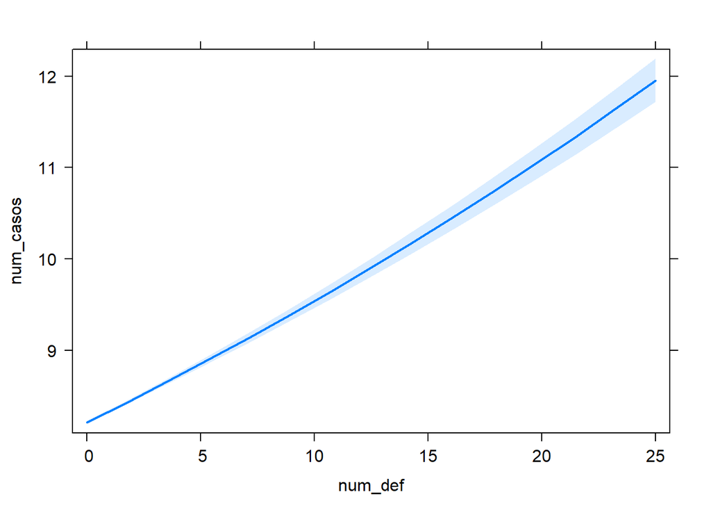

```r
plot(effect("muertes_17", fit.poisson), ci.style="band",
     rescale.axis=FALSE, multiline=TRUE, xlab="num_def", ylab="num_casos", rug=FALSE, main="")
```

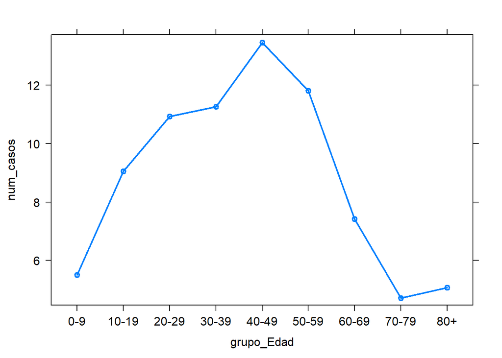

```r
plot(effect("grupo_edad", fit.poisson), ci.style="band",
     rescale.axis=FALSE, multiline=TRUE, xlab="grupo_Edad", ylab="num_casos", rug=FALSE, main="")
```

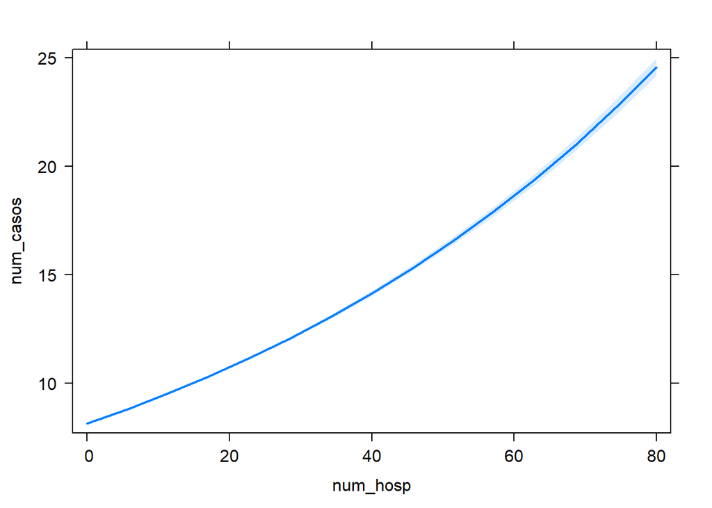

```r
plot(effect("hosp_10", fit.poisson), ci.style="band",
     rescale.axis=FALSE, multiline=TRUE, xlab="num_hosp", ylab="num_casos", rug=FALSE, main="")
```

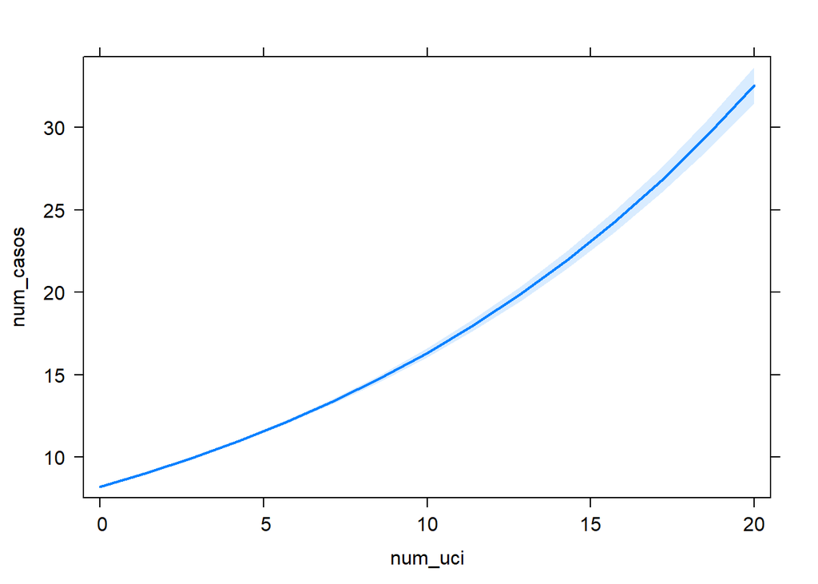

```r
plot(effect("uci_12", fit.poisson), ci.style="band",
     rescale.axis=FALSE, multiline=TRUE, xlab="num_uci", ylab="num_casos", rug=FALSE, main="")
```

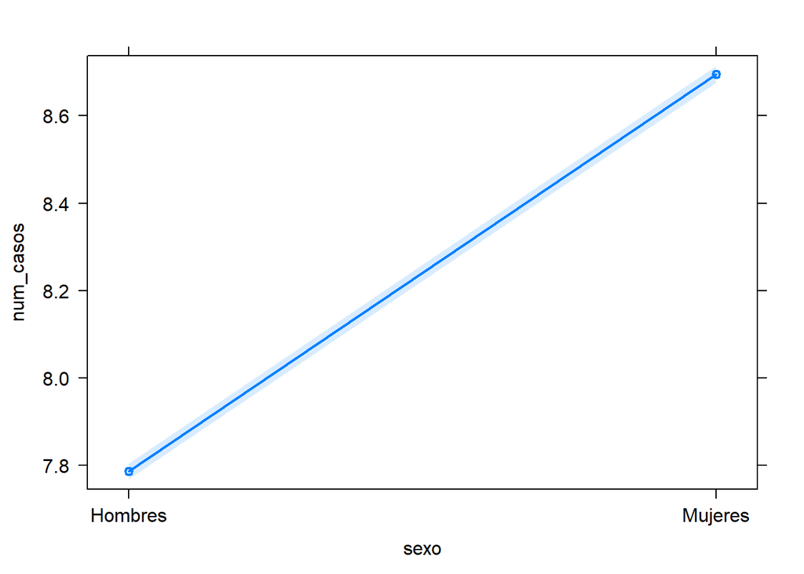

```r
plot(effect("sexo", fit.poisson), ci.style="band",
     rescale.axis=FALSE, multiline=TRUE, xlab="sexo", ylab="num_casos", rug=FALSE, main="")
```

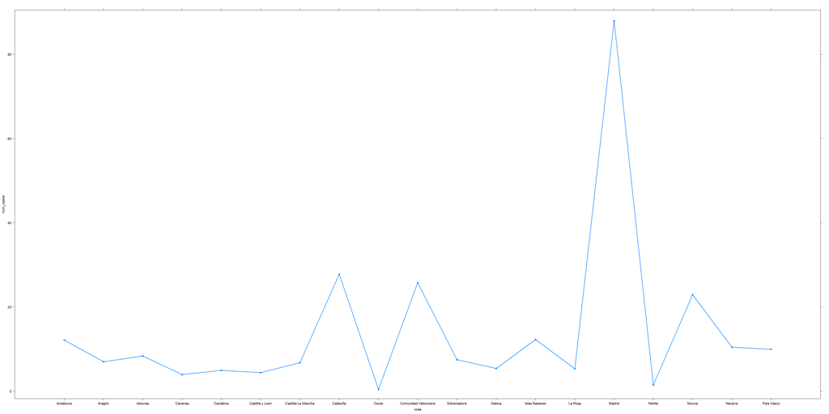

```r
plot(effect("ccaa", fit.poisson), ci.style="band",
     rescale.axis=FALSE, multiline=TRUE, xlab="ccaa", ylab="num_casos", rug=FALSE, main="")
```

Relación lineal positiva, aunque un poco exponencial, entre el número de defunciones y el número de casos. Relación exponencial entre el número de personas hospitalizados y en UCI frente al número de casos. Se confirma también en nuestro modelo, que las mujeres se contagian más.

Ahora vamos a crear nuevos modelos, con combinaciones entre predictores, para ver cual es el mejor. Lo usaremos para nuestra predicción.

```r
fit.poisson <- glm(num_casos ~ sexo + grupo_edad + ccaa + muertes_17 * hosp_10 * uci_12 , family = "poisson",data = casos_sin_fecha)

summary(fit.poisson)
```

```
##
## Call:
## glm(formula = num_casos ~ sexo + grupo_edad + ccaa + muertes_17 *
##     hosp_10 * uci_12, family = "poisson", data = casos_sin_fecha)
##
## Deviance Residuals:
##     Min       1Q   Median       3Q      Max
## -22.286   -2.995   -1.329    0.803   44.540
##
## Coefficients:
##                             Estimate Std. Error  z value Pr(>|z|)
## (Intercept)                2.009e+00  2.848e-03  705.504  < 2e-16 ***
## sexoMujeres                1.121e-01  1.242e-03   90.272  < 2e-16 ***
## grupo_edad10-19            4.974e-01  2.978e-03  167.047  < 2e-16 ***
## grupo_edad20-29            6.875e-01  2.876e-03  239.011  < 2e-16 ***
## grupo_edad30-39            7.162e-01  2.865e-03  249.981  < 2e-16 ***
## grupo_edad40-49            8.944e-01  2.786e-03  320.997  < 2e-16 ***
## grupo_edad50-59            7.641e-01  2.842e-03  268.871  < 2e-16 ***
## grupo_edad60-69            2.995e-01  3.097e-03   96.706  < 2e-16 ***
## grupo_edad70-79           -1.541e-01  3.453e-03  -44.640  < 2e-16 ***
## grupo_edad80+             -8.255e-02  3.382e-03  -24.407  < 2e-16 ***
## ccaaAragón                -5.490e-01  3.752e-03 -146.303  < 2e-16 ***
## ccaaAsturias              -3.759e-01  5.590e-03  -67.241  < 2e-16 ***
## ccaaCanarias              -1.121e+00  5.790e-03 -193.531  < 2e-16 ***
## ccaaCantabria             -8.945e-01  7.208e-03 -124.101  < 2e-16 ***
## ccaaCastilla y León       -1.006e+00  2.943e-03 -341.774  < 2e-16 ***
## ccaaCastilla-La Mancha    -5.799e-01  3.124e-03 -185.627  < 2e-16 ***
## ccaaCataluña               8.266e-01  2.161e-03  382.501  < 2e-16 ***
## ccaaCeuta                 -3.335e+00  2.406e-02 -138.624  < 2e-16 ***
## ccaaComunidad Valenciana   7.462e-01  2.367e-03  315.255  < 2e-16 ***
## ccaaExtremadura           -4.817e-01  4.339e-03 -111.014  < 2e-16 ***
## ccaaGalicia               -8.068e-01  3.714e-03 -217.206  < 2e-16 ***
## ccaaIslas Baleares         1.131e-02  4.717e-03    2.397   0.0165 *
## ccaaLa Rioja              -8.201e-01  6.948e-03 -118.033  < 2e-16 ***
## ccaaMadrid                 1.952e+00  2.637e-03  740.275  < 2e-16 ***
## ccaaMelilla               -2.106e+00  1.304e-02 -161.466  < 2e-16 ***
## ccaaMurcia                 6.254e-01  3.585e-03  174.453  < 2e-16 ***
## ccaaNavarra               -1.475e-01  5.071e-03  -29.082  < 2e-16 ***
## ccaaPaís Vasco            -1.985e-01  3.268e-03  -60.749  < 2e-16 ***
## muertes_17                 2.653e-02  6.065e-04   43.741  < 2e-16 ***
## hosp_10                    1.765e-02  1.226e-04  143.972  < 2e-16 ***
## uci_12                     1.177e-01  1.203e-03   97.828  < 2e-16 ***
## muertes_17:hosp_10        -7.916e-04  3.840e-05  -20.612  < 2e-16 ***
## muertes_17:uci_12         -5.131e-03  4.031e-04  -12.729  < 2e-16 ***
## hosp_10:uci_12            -3.857e-03  7.630e-05  -50.560  < 2e-16 ***
## muertes_17:hosp_10:uci_12  1.566e-04  2.088e-05    7.497 6.53e-14 ***
## ---
## Signif. codes:  0 '***' 0.001 '**' 0.01 '*' 0.05 '.' 0.1 ' ' 1
##
## (Dispersion parameter for poisson family taken to be 1)
##
##     Null deviance: 6025594  on 200286  degrees of freedom
## Residual deviance: 3344131  on 200252  degrees of freedom
##   (56 observations deleted due to missingness)
## AIC: 3956740
##
## Number of Fisher Scoring iterations: 6
```

```r
fit.poisson <- glm(num_casos ~ sexo +ccaa + grupo_edad + muertes_17  *uci_12 + hosp_10 * uci_12 , family = "poisson", data = casos_sin_fecha)

summary(fit.poisson)
```

```
##
## Call:
## glm(formula = num_casos ~ sexo + ccaa + grupo_edad + muertes_17 *
##     uci_12 + hosp_10 * uci_12, family = "poisson", data = casos_sin_fecha)
##
## Deviance Residuals:
##     Min       1Q   Median       3Q      Max
## -22.966   -2.997   -1.331    0.801   44.511
##
## Coefficients:
##                            Estimate Std. Error  z value Pr(>|z|)
## (Intercept)               2.011e+00  2.846e-03  706.506   <2e-16 ***
## sexoMujeres               1.122e-01  1.242e-03   90.342   <2e-16 ***
## ccaaAragón               -5.492e-01  3.752e-03 -146.356   <2e-16 ***
## ccaaAsturias             -3.749e-01  5.590e-03  -67.061   <2e-16 ***
## ccaaCanarias             -1.122e+00  5.790e-03 -193.782   <2e-16 ***
## ccaaCantabria            -8.958e-01  7.208e-03 -124.285   <2e-16 ***
## ccaaCastilla y León      -1.007e+00  2.943e-03 -342.174   <2e-16 ***
## ccaaCastilla-La Mancha   -5.809e-01  3.124e-03 -185.956   <2e-16 ***
## ccaaCataluña              8.269e-01  2.161e-03  382.686   <2e-16 ***
## ccaaCeuta                -3.337e+00  2.406e-02 -138.708   <2e-16 ***
## ccaaComunidad Valenciana  7.479e-01  2.366e-03  316.146   <2e-16 ***
## ccaaExtremadura          -4.823e-01  4.339e-03 -111.154   <2e-16 ***
## ccaaGalicia              -8.078e-01  3.714e-03 -217.503   <2e-16 ***
## ccaaIslas Baleares        1.058e-02  4.716e-03    2.242   0.0249 *
## ccaaLa Rioja             -8.211e-01  6.948e-03 -118.186   <2e-16 ***
## ccaaMadrid                1.956e+00  2.630e-03  743.911   <2e-16 ***
## ccaaMelilla              -2.108e+00  1.304e-02 -161.620   <2e-16 ***
## ccaaMurcia                6.265e-01  3.584e-03  174.776   <2e-16 ***
## ccaaNavarra              -1.479e-01  5.071e-03  -29.169   <2e-16 ***
## ccaaPaís Vasco           -1.988e-01  3.268e-03  -60.832   <2e-16 ***
## grupo_edad10-19           4.978e-01  2.978e-03  167.176   <2e-16 ***
## grupo_edad20-29           6.872e-01  2.876e-03  238.941   <2e-16 ***
## grupo_edad30-39           7.164e-01  2.865e-03  250.032   <2e-16 ***
## grupo_edad40-49           8.948e-01  2.786e-03  321.168   <2e-16 ***
## grupo_edad50-59           7.640e-01  2.842e-03  268.847   <2e-16 ***
## grupo_edad60-69           2.996e-01  3.097e-03   96.742   <2e-16 ***
## grupo_edad70-79          -1.537e-01  3.452e-03  -44.537   <2e-16 ***
## grupo_edad80+            -8.197e-02  3.382e-03  -24.239   <2e-16 ***
## muertes_17                1.838e-02  4.760e-04   38.604   <2e-16 ***
## uci_12                    1.172e-01  1.162e-03  100.781   <2e-16 ***
## hosp_10                   1.678e-02  1.160e-04  144.703   <2e-16 ***
## muertes_17:uci_12        -3.697e-03  2.775e-04  -13.324   <2e-16 ***
## uci_12:hosp_10           -3.701e-03  7.054e-05  -52.461   <2e-16 ***
## ---
## Signif. codes:  0 '***' 0.001 '**' 0.01 '*' 0.05 '.' 0.1 ' ' 1
##
## (Dispersion parameter for poisson family taken to be 1)
##
##     Null deviance: 6025594  on 200286  degrees of freedom
## Residual deviance: 3344591  on 200254  degrees of freedom
##   (56 observations deleted due to missingness)
## AIC: 3957196
##
## Number of Fisher Scoring iterations: 6
```

```r
fit.poisson <- glm(num_casos ~ sexo + grupo_edad * muertes_17 + grupo_edad * hosp_10 + grupo_edad * uci_12 + ccaa, family = "poisson", data = casos_sin_fecha)

summary(fit.poisson)
```

```
##
## Call:
## glm(formula = num_casos ~ sexo + grupo_edad * muertes_17 + grupo_edad *
##     hosp_10 + grupo_edad * uci_12 + ccaa, family = "poisson",
##     data = casos_sin_fecha)
##
## Deviance Residuals:
##     Min       1Q   Median       3Q      Max
## -24.166   -3.001   -1.337    0.802   44.412
##
## Coefficients:
##                              Estimate Std. Error  z value Pr(>|z|)
## (Intercept)                 2.0222737  0.0030306  667.286  < 2e-16 ***
## sexoMujeres                 0.1095313  0.0012427   88.139  < 2e-16 ***
## grupo_edad10-19             0.4948265  0.0033008  149.910  < 2e-16 ***
## grupo_edad20-29             0.6772619  0.0031702  213.635  < 2e-16 ***
## grupo_edad30-39             0.6983000  0.0031712  220.198  < 2e-16 ***
## grupo_edad40-49             0.8855859  0.0030822  287.324  < 2e-16 ***
## grupo_edad50-59             0.7580316  0.0031454  240.995  < 2e-16 ***
## grupo_edad60-69             0.3069807  0.0034200   89.760  < 2e-16 ***
## grupo_edad70-79            -0.1440824  0.0038178  -37.740  < 2e-16 ***
## grupo_edad80+              -0.0444866  0.0037446  -11.880  < 2e-16 ***
## muertes_17                  0.0179367  0.0015089   11.888  < 2e-16 ***
## hosp_10                     0.0148084  0.0003181   46.553  < 2e-16 ***
## uci_12                      0.0458460  0.0028487   16.094  < 2e-16 ***
## ccaaAragón                 -0.5508592  0.0037522 -146.810  < 2e-16 ***
## ccaaAsturias               -0.3735973  0.0055900  -66.833  < 2e-16 ***
## ccaaCanarias               -1.1241954  0.0057896 -194.174  < 2e-16 ***
## ccaaCantabria              -0.8980519  0.0072078 -124.595  < 2e-16 ***
## ccaaCastilla y León        -1.0107204  0.0029421 -343.532  < 2e-16 ***
## ccaaCastilla-La Mancha     -0.5849745  0.0031228 -187.324  < 2e-16 ***
## ccaaCataluña                0.8278807  0.0021609  383.119  < 2e-16 ***
## ccaaCeuta                  -3.3439301  0.0240599 -138.983  < 2e-16 ***
## ccaaComunidad Valenciana    0.7544622  0.0023657  318.920  < 2e-16 ***
## ccaaExtremadura            -0.4851984  0.0043392 -111.819  < 2e-16 ***
## ccaaGalicia                -0.8094617  0.0037139 -217.955  < 2e-16 ***
## ccaaIslas Baleares          0.0116330  0.0047166    2.466 0.013648 *
## ccaaLa Rioja               -0.8229200  0.0069475 -118.448  < 2e-16 ***
## ccaaMadrid                  1.9774856  0.0026023  759.912  < 2e-16 ***
## ccaaMelilla                -2.1123819  0.0130410 -161.980  < 2e-16 ***
```

[output cut: 23 more lines]

```
## grupo_edad50-59:uci_12      0.0228354  0.0035917    6.358 2.05e-10 ***
## grupo_edad60-69:uci_12      0.0022166  0.0040833    0.543 0.587243
## grupo_edad70-79:uci_12     -0.0185216  0.0048901   -3.788 0.000152 ***
## grupo_edad80+:uci_12       -0.0264720  0.0045632   -5.801 6.58e-09 ***
## ---
## Signif. codes:  0 '***' 0.001 '**' 0.01 '*' 0.05 '.' 0.1 ' ' 1
##
## (Dispersion parameter for poisson family taken to be 1)
##
##     Null deviance: 6025594  on 200286  degrees of freedom
## Residual deviance: 3344429  on 200232  degrees of freedom
##   (56 observations deleted due to missingness)
## AIC: 3957077
##
## Number of Fisher Scoring iterations: 6
```

```r
fit.poisson <- glm(num_casos ~ sexo + muertes_17 + hosp_10 + grupo_edad * uci_12 + ccaa, family = "poisson", data = casos_sin_fecha)

summary(fit.poisson)
```

```
##
## Call:
## glm(formula = num_casos ~ sexo + muertes_17 + hosp_10 + grupo_edad *
##     uci_12 + ccaa, family = "poisson", data = casos_sin_fecha)
##
## Deviance Residuals:
##     Min       1Q   Median       3Q      Max
## -26.559   -3.000   -1.332    0.808   44.395
##
## Coefficients:
##                            Estimate Std. Error  z value Pr(>|z|)
## (Intercept)               2.0250600  0.0029247  692.401  < 2e-16 ***
## sexoMujeres               0.1098048  0.0012421   88.403  < 2e-16 ***
## muertes_17                0.0147899  0.0004091   36.155  < 2e-16 ***
## hosp_10                   0.0139287  0.0001037  134.359  < 2e-16 ***
## grupo_edad10-19           0.4934517  0.0031222  158.045  < 2e-16 ***
## grupo_edad20-29           0.6696364  0.0030140  222.173  < 2e-16 ***
## grupo_edad30-39           0.7075380  0.0029937  236.341  < 2e-16 ***
## grupo_edad40-49           0.8851674  0.0029149  303.668  < 2e-16 ***
## grupo_edad50-59           0.7575957  0.0029683  255.230  < 2e-16 ***
## grupo_edad60-69           0.2988647  0.0032320   92.470  < 2e-16 ***
## grupo_edad70-79          -0.1495323  0.0036109  -41.411  < 2e-16 ***
## grupo_edad80+            -0.0694628  0.0035361  -19.644  < 2e-16 ***
## uci_12                    0.0492198  0.0026745   18.403  < 2e-16 ***
## ccaaAragón               -0.5508794  0.0037521 -146.817  < 2e-16 ***
## ccaaAsturias             -0.3731670  0.0055898  -66.759  < 2e-16 ***
## ccaaCanarias             -1.1242563  0.0057896 -194.185  < 2e-16 ***
## ccaaCantabria            -0.8981585  0.0072077 -124.611  < 2e-16 ***
## ccaaCastilla y León      -1.0107190  0.0029421 -343.535  < 2e-16 ***
## ccaaCastilla-La Mancha   -0.5850791  0.0031227 -187.360  < 2e-16 ***
## ccaaCataluña              0.8279730  0.0021608  383.178  < 2e-16 ***
## ccaaCeuta                -3.3440488  0.0240599 -138.988  < 2e-16 ***
## ccaaComunidad Valenciana  0.7537178  0.0023642  318.808  < 2e-16 ***
## ccaaExtremadura          -0.4851597  0.0043391 -111.810  < 2e-16 ***
## ccaaGalicia              -0.8095064  0.0037139 -217.968  < 2e-16 ***
## ccaaIslas Baleares        0.0115259  0.0047165    2.444   0.0145 *
## ccaaLa Rioja             -0.8229967  0.0069475 -118.460  < 2e-16 ***
## ccaaMadrid                1.9796775  0.0025968  762.355  < 2e-16 ***
## ccaaMelilla              -2.1129868  0.0130410 -162.027  < 2e-16 ***
## ccaaMurcia                0.6356453  0.0035806  177.524  < 2e-16 ***
## ccaaNavarra              -0.1485008  0.0050709  -29.285  < 2e-16 ***
## ccaaPaís Vasco           -0.2008157  0.0032677  -61.455  < 2e-16 ***
## grupo_edad10-19:uci_12    0.0150690  0.0038037    3.962 7.44e-05 ***
## grupo_edad20-29:uci_12    0.0612769  0.0032268   18.990  < 2e-16 ***
## grupo_edad30-39:uci_12    0.0313572  0.0032624    9.612  < 2e-16 ***
## grupo_edad40-49:uci_12    0.0348584  0.0032920   10.589  < 2e-16 ***
## grupo_edad50-59:uci_12    0.0221081  0.0033745    6.551 5.70e-11 ***
## grupo_edad60-69:uci_12   -0.0087450  0.0038120   -2.294   0.0218 *
## grupo_edad70-79:uci_12   -0.0262310  0.0045957   -5.708 1.14e-08 ***
## grupo_edad80+:uci_12     -0.0581043  0.0043314  -13.415  < 2e-16 ***
## ---
## Signif. codes:  0 '***' 0.001 '**' 0.01 '*' 0.05 '.' 0.1 ' ' 1
##
## (Dispersion parameter for poisson family taken to be 1)
##
##     Null deviance: 6025594  on 200286  degrees of freedom
## Residual deviance: 3346552  on 200248  degrees of freedom
##   (56 observations deleted due to missingness)
## AIC: 3959169
##
## Number of Fisher Scoring iterations: 6
```

```r
fit.poisson <- glm(num_casos ~  muertes_17 + hosp_10 + grupo_edad * uci_12 + sexo * uci_12 + ccaa, family = "poisson", data = casos_sin_fecha)

summary(fit.poisson)
```

```
##
## Call:
## glm(formula = num_casos ~ muertes_17 + hosp_10 + grupo_edad *
##     uci_12 + sexo * uci_12 + ccaa, family = "poisson", data = casos_sin_fecha)
##
## Deviance Residuals:
##     Min       1Q   Median       3Q      Max
## -24.975   -2.999   -1.339    0.805   44.359
##
## Coefficients:
##                            Estimate Std. Error  z value Pr(>|z|)
## (Intercept)               2.0288369  0.0029310  692.188  < 2e-16 ***
## muertes_17                0.0150053  0.0004091   36.681  < 2e-16 ***
## hosp_10                   0.0138604  0.0001037  133.634  < 2e-16 ***
## grupo_edad10-19           0.4929943  0.0031225  157.883  < 2e-16 ***
## grupo_edad20-29           0.6691819  0.0030142  222.012  < 2e-16 ***
## grupo_edad30-39           0.7076168  0.0029935  236.388  < 2e-16 ***
## grupo_edad40-49           0.8853515  0.0029146  303.759  < 2e-16 ***
## grupo_edad50-59           0.7575612  0.0029680  255.242  < 2e-16 ***
## grupo_edad60-69           0.2981295  0.0032330   92.213  < 2e-16 ***
## grupo_edad70-79          -0.1499021  0.0036110  -41.512  < 2e-16 ***
## grupo_edad80+            -0.0701350  0.0035370  -19.829  < 2e-16 ***
## uci_12                    0.0294647  0.0028798   10.231  < 2e-16 ***
## sexoMujeres               0.1029577  0.0012935   79.596  < 2e-16 ***
## ccaaAragón               -0.5508299  0.0037521 -146.804  < 2e-16 ***
## ccaaAsturias             -0.3731433  0.0055898  -66.755  < 2e-16 ***
## ccaaCanarias             -1.1242035  0.0057896 -194.176  < 2e-16 ***
## ccaaCantabria            -0.8980002  0.0072077 -124.589  < 2e-16 ***
## ccaaCastilla y León      -1.0106713  0.0029421 -343.519  < 2e-16 ***
## ccaaCastilla-La Mancha   -0.5850884  0.0031227 -187.363  < 2e-16 ***
## ccaaCataluña              0.8280050  0.0021608  383.192  < 2e-16 ***
## ccaaCeuta                -3.3440134  0.0240599 -138.987  < 2e-16 ***
## ccaaComunidad Valenciana  0.7541746  0.0023643  318.985  < 2e-16 ***
## ccaaExtremadura          -0.4851547  0.0043391 -111.809  < 2e-16 ***
## ccaaGalicia              -0.8095646  0.0037139 -217.984  < 2e-16 ***
## ccaaIslas Baleares        0.0118660  0.0047166    2.516   0.0119 *
## ccaaLa Rioja             -0.8229569  0.0069475 -118.454  < 2e-16 ***
## ccaaMadrid                1.9800403  0.0025966  762.544  < 2e-16 ***
## ccaaMelilla              -2.1134371  0.0130410 -162.060  < 2e-16 ***
## ccaaMurcia                0.6361051  0.0035807  177.649  < 2e-16 ***
## ccaaNavarra              -0.1483625  0.0050709  -29.258  < 2e-16 ***
## ccaaPaís Vasco           -0.2008458  0.0032677  -61.464  < 2e-16 ***
## grupo_edad10-19:uci_12    0.0207629  0.0038202    5.435 5.48e-08 ***
## grupo_edad20-29:uci_12    0.0675692  0.0032438   20.830  < 2e-16 ***
## grupo_edad30-39:uci_12    0.0329922  0.0032592   10.123  < 2e-16 ***
## grupo_edad40-49:uci_12    0.0364021  0.0032882   11.070  < 2e-16 ***
## grupo_edad50-59:uci_12    0.0255034  0.0033738    7.559 4.05e-14 ***
## grupo_edad60-69:uci_12   -0.0004970  0.0038532   -0.129   0.8974
## grupo_edad70-79:uci_12   -0.0191310  0.0046119   -4.148 3.35e-05 ***
## grupo_edad80+:uci_12     -0.0477354  0.0043801  -10.898  < 2e-16 ***
## uci_12:sexoMujeres        0.0302231  0.0015978   18.916  < 2e-16 ***
## ---
## Signif. codes:  0 '***' 0.001 '**' 0.01 '*' 0.05 '.' 0.1 ' ' 1
##
## (Dispersion parameter for poisson family taken to be 1)
##
##     Null deviance: 6025594  on 200286  degrees of freedom
## Residual deviance: 3346193  on 200247  degrees of freedom
##   (56 observations deleted due to missingness)
## AIC: 3958812
##
## Number of Fisher Scoring iterations: 6
```

```r
fit.poisson <- glm(num_casos ~ muertes_17 + hosp_10 + grupo_edad * uci_12 + sexo * uci_12 + ccaa, family = "poisson", data = casos_sin_fecha)

summary(fit.poisson)
```

```
##
## Call:
## glm(formula = num_casos ~ muertes_17 + hosp_10 + grupo_edad *
##     uci_12 + sexo * uci_12 + ccaa, family = "poisson", data = casos_sin_fecha)
##
## Deviance Residuals:
##     Min       1Q   Median       3Q      Max
## -24.975   -2.999   -1.339    0.805   44.359
##
## Coefficients:
##                            Estimate Std. Error  z value Pr(>|z|)
## (Intercept)               2.0288369  0.0029310  692.188  < 2e-16 ***
## muertes_17                0.0150053  0.0004091   36.681  < 2e-16 ***
## hosp_10                   0.0138604  0.0001037  133.634  < 2e-16 ***
## grupo_edad10-19           0.4929943  0.0031225  157.883  < 2e-16 ***
## grupo_edad20-29           0.6691819  0.0030142  222.012  < 2e-16 ***
## grupo_edad30-39           0.7076168  0.0029935  236.388  < 2e-16 ***
## grupo_edad40-49           0.8853515  0.0029146  303.759  < 2e-16 ***
## grupo_edad50-59           0.7575612  0.0029680  255.242  < 2e-16 ***
## grupo_edad60-69           0.2981295  0.0032330   92.213  < 2e-16 ***
## grupo_edad70-79          -0.1499021  0.0036110  -41.512  < 2e-16 ***
## grupo_edad80+            -0.0701350  0.0035370  -19.829  < 2e-16 ***
## uci_12                    0.0294647  0.0028798   10.231  < 2e-16 ***
## sexoMujeres               0.1029577  0.0012935   79.596  < 2e-16 ***
## ccaaAragón               -0.5508299  0.0037521 -146.804  < 2e-16 ***
## ccaaAsturias             -0.3731433  0.0055898  -66.755  < 2e-16 ***
## ccaaCanarias             -1.1242035  0.0057896 -194.176  < 2e-16 ***
## ccaaCantabria            -0.8980002  0.0072077 -124.589  < 2e-16 ***
## ccaaCastilla y León      -1.0106713  0.0029421 -343.519  < 2e-16 ***
## ccaaCastilla-La Mancha   -0.5850884  0.0031227 -187.363  < 2e-16 ***
## ccaaCataluña              0.8280050  0.0021608  383.192  < 2e-16 ***
## ccaaCeuta                -3.3440134  0.0240599 -138.987  < 2e-16 ***
## ccaaComunidad Valenciana  0.7541746  0.0023643  318.985  < 2e-16 ***
## ccaaExtremadura          -0.4851547  0.0043391 -111.809  < 2e-16 ***
## ccaaGalicia              -0.8095646  0.0037139 -217.984  < 2e-16 ***
## ccaaIslas Baleares        0.0118660  0.0047166    2.516   0.0119 *
## ccaaLa Rioja             -0.8229569  0.0069475 -118.454  < 2e-16 ***
## ccaaMadrid                1.9800403  0.0025966  762.544  < 2e-16 ***
## ccaaMelilla              -2.1134371  0.0130410 -162.060  < 2e-16 ***
## ccaaMurcia                0.6361051  0.0035807  177.649  < 2e-16 ***
## ccaaNavarra              -0.1483625  0.0050709  -29.258  < 2e-16 ***
## ccaaPaís Vasco           -0.2008458  0.0032677  -61.464  < 2e-16 ***
## grupo_edad10-19:uci_12    0.0207629  0.0038202    5.435 5.48e-08 ***
## grupo_edad20-29:uci_12    0.0675692  0.0032438   20.830  < 2e-16 ***
## grupo_edad30-39:uci_12    0.0329922  0.0032592   10.123  < 2e-16 ***
## grupo_edad40-49:uci_12    0.0364021  0.0032882   11.070  < 2e-16 ***
## grupo_edad50-59:uci_12    0.0255034  0.0033738    7.559 4.05e-14 ***
## grupo_edad60-69:uci_12   -0.0004970  0.0038532   -0.129   0.8974
## grupo_edad70-79:uci_12   -0.0191310  0.0046119   -4.148 3.35e-05 ***
## grupo_edad80+:uci_12     -0.0477354  0.0043801  -10.898  < 2e-16 ***
## uci_12:sexoMujeres        0.0302231  0.0015978   18.916  < 2e-16 ***
## ---
## Signif. codes:  0 '***' 0.001 '**' 0.01 '*' 0.05 '.' 0.1 ' ' 1
##
## (Dispersion parameter for poisson family taken to be 1)
##
##     Null deviance: 6025594  on 200286  degrees of freedom
## Residual deviance: 3346193  on 200247  degrees of freedom
##   (56 observations deleted due to missingness)
## AIC: 3958812
##
## Number of Fisher Scoring iterations: 6
```

```r
fit.poisson <- glm(num_casos ~ muertes_17 + hosp_10 + grupo_edad + uci_12 + sexo * uci_12 + ccaa, family = "poisson", data = casos_sin_fecha)

summary(fit.poisson)
```

```
##
## Call:
## glm(formula = num_casos ~ muertes_17 + hosp_10 + grupo_edad +
##     uci_12 + sexo * uci_12 + ccaa, family = "poisson", data = casos_sin_fecha)
##
## Deviance Residuals:
##     Min       1Q   Median       3Q      Max
## -22.991   -2.996   -1.338    0.804   44.364
##
## Coefficients:
##                            Estimate Std. Error  z value Pr(>|z|)
## (Intercept)               2.0222205  0.0028453  710.711   <2e-16 ***
## muertes_17                0.0152773  0.0004081   37.438   <2e-16 ***
## hosp_10                   0.0137724  0.0001036  132.946   <2e-16 ***
## grupo_edad10-19           0.4993883  0.0029784  167.668   <2e-16 ***
## grupo_edad20-29           0.6878121  0.0028766  239.106   <2e-16 ***
## grupo_edad30-39           0.7167578  0.0028654  250.144   <2e-16 ***
## grupo_edad40-49           0.8951185  0.0027864  321.243   <2e-16 ***
## grupo_edad50-59           0.7649345  0.0028422  269.134   <2e-16 ***
## grupo_edad60-69           0.3001083  0.0030983   96.864   <2e-16 ***
## grupo_edad70-79          -0.1519190  0.0034532  -43.994   <2e-16 ***
## grupo_edad80+            -0.0794412  0.0033836  -23.478   <2e-16 ***
## uci_12                    0.0515734  0.0011924   43.252   <2e-16 ***
## sexoMujeres               0.1025371  0.0012931   79.295   <2e-16 ***
## ccaaAragón               -0.5507312  0.0037521 -146.779   <2e-16 ***
## ccaaAsturias             -0.3733124  0.0055897  -66.785   <2e-16 ***
## ccaaCanarias             -1.1243939  0.0057896 -194.210   <2e-16 ***
## ccaaCantabria            -0.8982177  0.0072076 -124.622   <2e-16 ***
## ccaaCastilla y León      -1.0106468  0.0029421 -343.514   <2e-16 ***
## ccaaCastilla-La Mancha   -0.5851297  0.0031227 -187.379   <2e-16 ***
## ccaaCataluña              0.8277822  0.0021607  383.101   <2e-16 ***
## ccaaCeuta                -3.3440415  0.0240599 -138.988   <2e-16 ***
## ccaaComunidad Valenciana  0.7531783  0.0023638  318.628   <2e-16 ***
## ccaaExtremadura          -0.4850584  0.0043391 -111.788   <2e-16 ***
## ccaaGalicia              -0.8097942  0.0037138 -218.047   <2e-16 ***
## ccaaIslas Baleares        0.0117317  0.0047165    2.487   0.0129 *
## ccaaLa Rioja             -0.8229918  0.0069475 -118.459   <2e-16 ***
## ccaaMadrid                1.9804804  0.0025950  763.182   <2e-16 ***
## ccaaMelilla              -2.1133552  0.0130409 -162.056   <2e-16 ***
## ccaaMurcia                0.6363973  0.0035804  177.743   <2e-16 ***
## ccaaNavarra              -0.1485324  0.0050709  -29.291   <2e-16 ***
## ccaaPaís Vasco           -0.2009182  0.0032677  -61.487   <2e-16 ***
## uci_12:sexoMujeres        0.0341063  0.0015687   21.741   <2e-16 ***
## ---
## Signif. codes:  0 '***' 0.001 '**' 0.01 '*' 0.05 '.' 0.1 ' ' 1
##
## (Dispersion parameter for poisson family taken to be 1)
##
##     Null deviance: 6025594  on 200286  degrees of freedom
## Residual deviance: 3347566  on 200255  degrees of freedom
##   (56 observations deleted due to missingness)
## AIC: 3960169
##
## Number of Fisher Scoring iterations: 6
```

```r
fit.poisson <- glm(num_casos ~ muertes_17 , family = "poisson", data = casos_sin_fecha)

summary(fit.poisson)
```

```
##
## Call:
## glm(formula = num_casos ~ muertes_17, family = "poisson", data = casos_sin_fecha)
##
## Deviance Residuals:
##     Min       1Q   Median       3Q      Max
## -30.172   -4.244   -2.816   -0.152   69.117
##
## Coefficients:
##              Estimate Std. Error z value Pr(>|z|)
## (Intercept) 2.5285257  0.0006334  3992.2   <2e-16 ***
## muertes_17  0.1545918  0.0003425   451.4   <2e-16 ***
## ---
## Signif. codes:  0 '***' 0.001 '**' 0.01 '*' 0.05 '.' 0.1 ' ' 1
##
## (Dispersion parameter for poisson family taken to be 1)
##
##     Null deviance: 6025594  on 200286  degrees of freedom
## Residual deviance: 5909023  on 200285  degrees of freedom
##   (56 observations deleted due to missingness)
## AIC: 6521566
##
## Number of Fisher Scoring iterations: 6
```

El mejor modelo tiene esta forma:

num_casos ~ sexo + grupo_edad + ccaa + muertes_17 * hosp_10 * uci_12

- Null deviance: 6025594 on 200286 degrees of freedom
- Residual deviance: 3344131 on 200252 degrees of freedom (56 observations deleted due to missingness)
- AIC: 3956740

Para ver si nuestro modelo tiene sobredispersión, es decir, existe mucha varianza para su media, hacemos GLM con la familia de la quasipoisson. Los modelos con familia quasipoisson no los podemos comparar, no nos da el estadístico AIC por su naturaleza.

```r
fit.qpoisson <- glm(num_casos ~ sexo + grupo_edad + ccaa + muertes_17 * hosp_10 * uci_12 , family = "quasipoisson", data = casos_sin_fecha)
summary(fit.qpoisson)
```

```
##
## Call:
## glm(formula = num_casos ~ sexo + grupo_edad + ccaa + muertes_17 *
##     hosp_10 * uci_12, family = "quasipoisson", data = casos_sin_fecha)
##
## Deviance Residuals:
##     Min       1Q   Median       3Q      Max
## -22.286   -2.995   -1.329    0.803   44.540
##
## Coefficients:
##                             Estimate Std. Error t value Pr(>|t|)
## (Intercept)                2.0091496  0.0136889 146.772  < 2e-16 ***
## sexoMujeres                0.1121279  0.0059706  18.780  < 2e-16 ***
## grupo_edad10-19            0.4973970  0.0143127  34.752  < 2e-16 ***
## grupo_edad20-29            0.6874651  0.0138258  49.723  < 2e-16 ***
## grupo_edad30-39            0.7161962  0.0137715  52.006  < 2e-16 ***
## grupo_edad40-49            0.8943641  0.0133928  66.780  < 2e-16 ***
## grupo_edad50-59            0.7640875  0.0136602  55.935  < 2e-16 ***
## grupo_edad60-69            0.2995315  0.0148884  20.118  < 2e-16 ***
## grupo_edad70-79           -0.1541209  0.0165957  -9.287  < 2e-16 ***
## grupo_edad80+             -0.0825484  0.0162573  -5.078 3.83e-07 ***
## ccaaAragón                -0.5489663  0.0180364 -30.437  < 2e-16 ***
## ccaaAsturias              -0.3758861  0.0268706 -13.989  < 2e-16 ***
## ccaaCanarias              -1.1205769  0.0278322 -40.262  < 2e-16 ***
## ccaaCantabria             -0.8945209  0.0346475 -25.818  < 2e-16 ***
## ccaaCastilla y León       -1.0059537  0.0141480 -71.102  < 2e-16 ***
## ccaaCastilla-La Mancha    -0.5799047  0.0150166 -38.617  < 2e-16 ***
## ccaaCataluña               0.8265502  0.0103871  79.575  < 2e-16 ***
## ccaaCeuta                 -3.3353474  0.1156539 -28.839  < 2e-16 ***
## ccaaComunidad Valenciana   0.7462344  0.0113781  65.585  < 2e-16 ***
## ccaaExtremadura           -0.4817444  0.0208591 -23.095  < 2e-16 ***
## ccaaGalicia               -0.8067797  0.0178542 -45.187  < 2e-16 ***
## ccaaIslas Baleares         0.0113076  0.0226718   0.499   0.6180
## ccaaLa Rioja              -0.8200649  0.0333966 -24.555  < 2e-16 ***
## ccaaMadrid                 1.9520220  0.0126750 154.006  < 2e-16 ***
## ccaaMelilla               -2.1058048  0.0626892 -33.591  < 2e-16 ***
## ccaaMurcia                 0.6253994  0.0172320  36.293  < 2e-16 ***
## ccaaNavarra               -0.1474719  0.0243751  -6.050 1.45e-09 ***
## ccaaPaís Vasco            -0.1985239  0.0157083 -12.638  < 2e-16 ***
## muertes_17                 0.0265303  0.0029155   9.100  < 2e-16 ***
## hosp_10                    0.0176530  0.0005894  29.952  < 2e-16 ***
## uci_12                     0.1176556  0.0057810  20.352  < 2e-16 ***
## muertes_17:hosp_10        -0.0007915  0.0001846  -4.288 1.80e-05 ***
## muertes_17:uci_12         -0.0051311  0.0019377  -2.648   0.0081 **
## hosp_10:uci_12            -0.0038575  0.0003667 -10.518  < 2e-16 ***
## muertes_17:hosp_10:uci_12  0.0001566  0.0001004   1.560   0.1188
## ---
## Signif. codes:  0 '***' 0.001 '**' 0.01 '*' 0.05 '.' 0.1 ' ' 1
##
## (Dispersion parameter for quasipoisson family taken to be 23.10542)
##
##     Null deviance: 6025594  on 200286  degrees of freedom
## Residual deviance: 3344131  on 200252  degrees of freedom
##   (56 observations deleted due to missingness)
## AIC: NA
##
## Number of Fisher Scoring iterations: 6
```

Sobredispersión muy alta. Veamos los efectos entre los predictores y el Target.

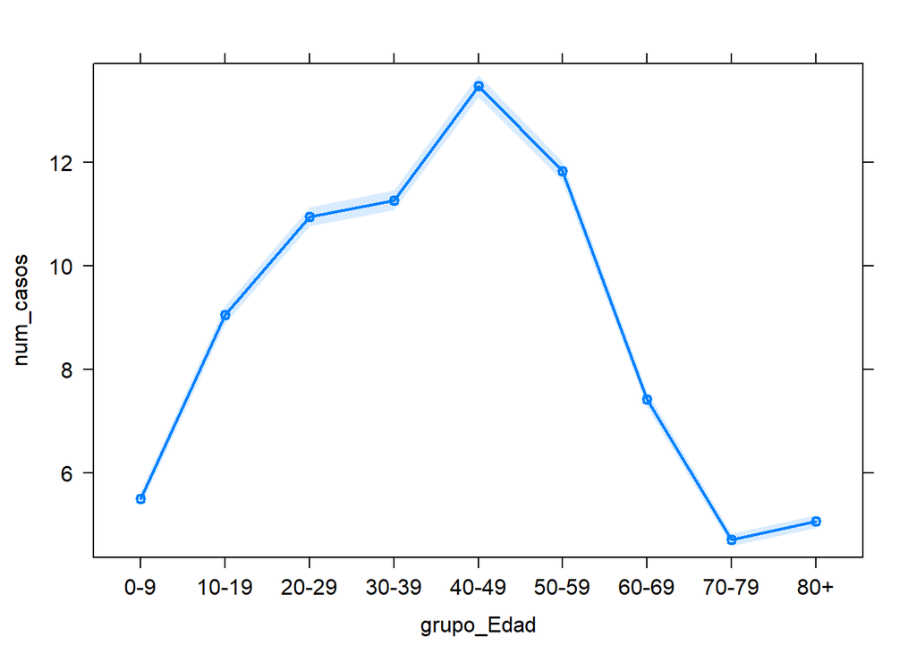

```r
plot(effect("grupo_edad", fit.qpoisson), ci.style="band",
     rescale.axis=FALSE, multiline=TRUE, xlab="grupo_Edad", ylab="num_casos", rug=FALSE, main="")
```

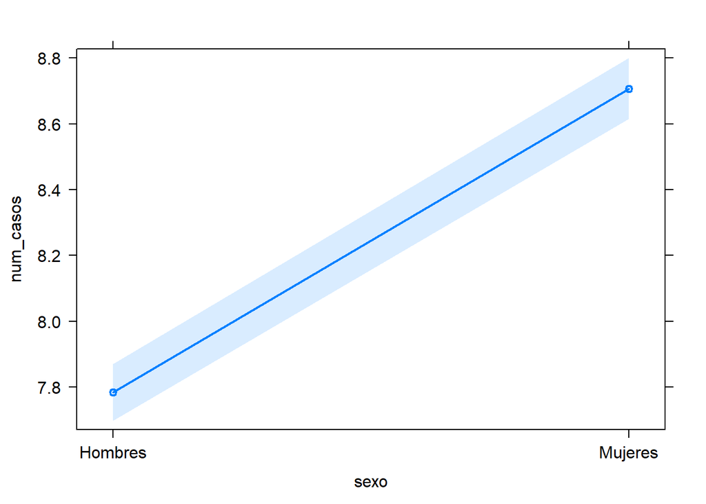

```r
plot(effect("sexo", fit.qpoisson), ci.style="band",
     rescale.axis=FALSE, multiline=TRUE, xlab="sexo", ylab="num_casos", rug=FALSE, main="")
```

```r
plot(effect("ccaa", fit.qpoisson), ci.style="band",
     rescale.axis=FALSE, multiline=TRUE, xlab="ccaa", ylab="num_casos", rug=FALSE, main="")
```

[figure not shown]

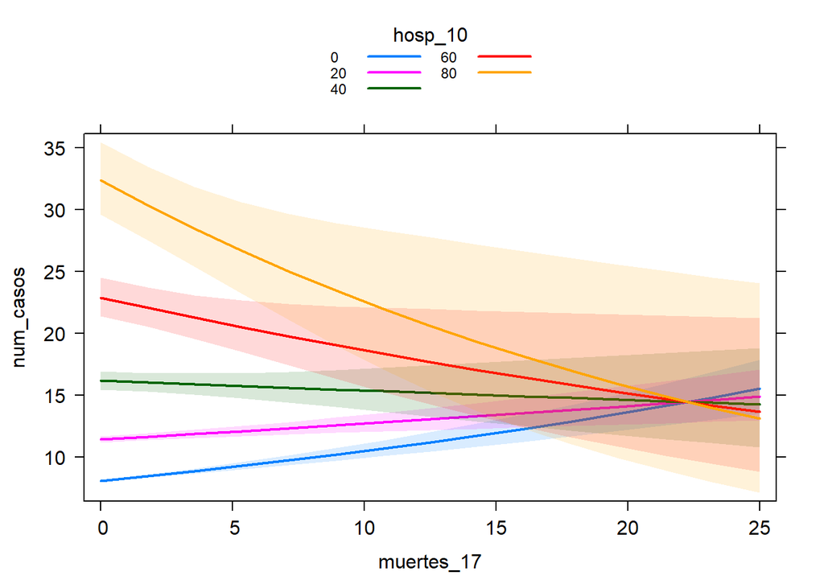

```r
plot(effect("muertes_17:hosp_10", fit.qpoisson), ci.style="band",
     rescale.axis=FALSE, multiline=TRUE, xlab="muertes_17", ylab="num_casos", rug=FALSE, main="")
```

Lo que nos muestra este gráfico es la existencia de ciclos en la pandemia. El número de nuevos fallecidos siempre converge en un punto, es decir, no siempre es creciente o siempre decreciente, sino que fluctua. Además, muestra que a mayor número de hospitalizados, mayor es el número de casos cuando las muertes son bajas.

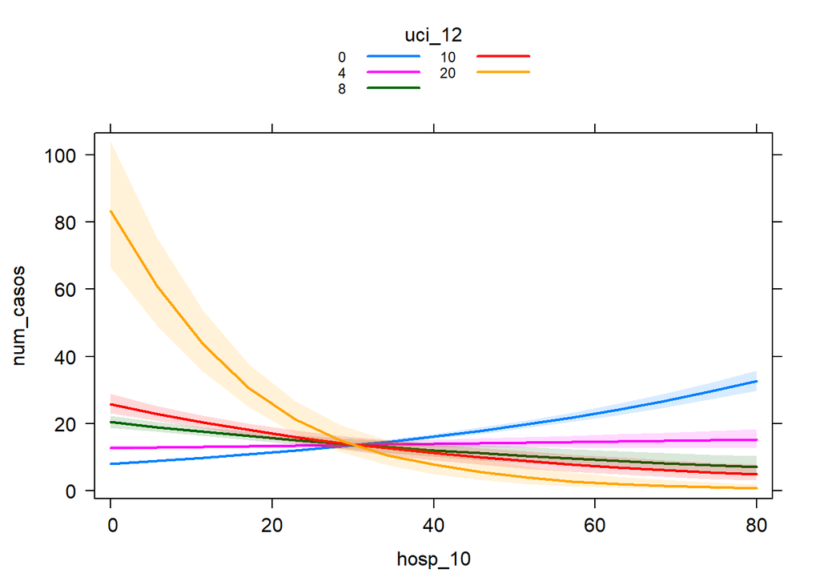

```r
plot(effect("hosp_10:uci_12", fit.qpoisson), ci.style="band",
     rescale.axis=FALSE, multiline=TRUE, xlab="hosp_10", ylab="num_casos", rug=FALSE, main="")
```

Se confirma la hipótesis anterior, el número de casos converge en un mismo punto, independientemente de si la situación actual fuese buena o mala.

En términos generales se observan discriminaciones muy similares al modelo inicial con todas las variables.

Como hemos visto, un modelo inflado con cero es un modelo estadístico basado en una distribución de probabilidad inflada con cero , es decir, una distribución que permite observaciones frecuentes de valor cero. Modelo inflado cero.

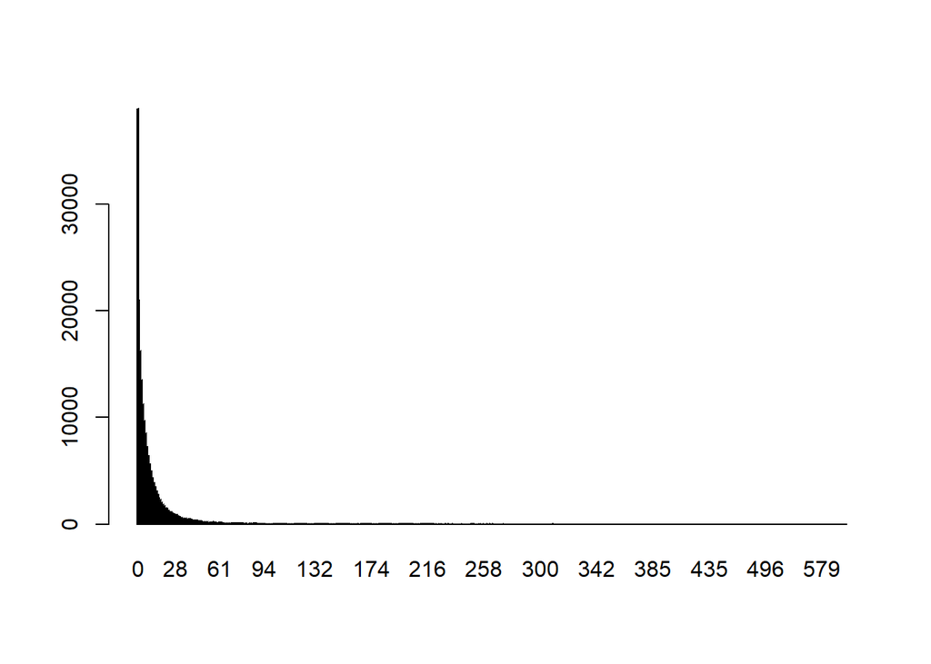

```r
barplot(table(casos_sin_fecha$num_casos))
```

Confirmamos que en nuestros datos hay gran cantidad de observaciones, número de casos, que son cero. Por ello crearemos otro modelo con zero-inflado y lo usaremos para predecir.

```r
fit.zip1 = zeroinfl(num_casos ~ sexo + grupo_edad + ccaa + muertes_17 * hosp_10 * uci_12 ,data = casos_sin_fecha)
summary(fit.zip1)
```

```
##
## Call:
## zeroinfl(formula = num_casos ~ sexo + grupo_edad + ccaa + muertes_17 *
##     hosp_10 * uci_12, data = casos_sin_fecha)
##
## Pearson residuals:
##      Min       1Q   Median       3Q      Max
## -13.1165  -1.4277  -0.7418   0.5436  54.2389
##
## Count model coefficients (poisson with log link):
##                             Estimate Std. Error  z value Pr(>|z|)
## (Intercept)                2.226e+00  2.862e-03  777.896   <2e-16 ***
## sexoMujeres                1.104e-01  1.244e-03   88.718   <2e-16 ***
## grupo_edad10-19            4.530e-01  2.988e-03  151.604   <2e-16 ***
## grupo_edad20-29            6.055e-01  2.886e-03  209.774   <2e-16 ***
## grupo_edad30-39            6.374e-01  2.876e-03  221.670   <2e-16 ***
## grupo_edad40-49            8.123e-01  2.797e-03  290.420   <2e-16 ***
## grupo_edad50-59            6.923e-01  2.852e-03  242.724   <2e-16 ***
## grupo_edad60-69            2.645e-01  3.109e-03   85.085   <2e-16 ***
## grupo_edad70-79           -1.390e-01  3.483e-03  -39.909   <2e-16 ***
## grupo_edad80+             -4.897e-02  3.401e-03  -14.399   <2e-16 ***
## ccaaAragón                -5.514e-01  3.761e-03 -146.625   <2e-16 ***
## ccaaAsturias              -3.572e-01  5.595e-03  -63.831   <2e-16 ***
## ccaaCanarias              -1.051e+00  5.887e-03 -178.532   <2e-16 ***
## ccaaCantabria             -9.050e-01  7.284e-03 -124.256   <2e-16 ***
## ccaaCastilla y León       -8.368e-01  2.961e-03 -282.622   <2e-16 ***
## ccaaCastilla-La Mancha    -5.419e-01  3.131e-03 -173.077   <2e-16 ***
## ccaaCataluña               7.131e-01  2.161e-03  329.996   <2e-16 ***
## ccaaCeuta                 -2.584e+00  3.405e-02  -75.898   <2e-16 ***
## ccaaComunidad Valenciana   6.829e-01  2.367e-03  288.530   <2e-16 ***
## ccaaExtremadura           -4.472e-01  4.346e-03 -102.899   <2e-16 ***
## ccaaGalicia               -7.216e-01  3.731e-03 -193.440   <2e-16 ***
## ccaaIslas Baleares        -5.426e-02  4.717e-03  -11.503   <2e-16 ***
## ccaaLa Rioja              -7.949e-01  6.995e-03 -113.647   <2e-16 ***
## ccaaMadrid                 1.818e+00  2.637e-03  689.303   <2e-16 ***
## ccaaMelilla               -1.767e+00  1.442e-02 -122.613   <2e-16 ***
## ccaaMurcia                 5.428e-01  3.586e-03  151.360   <2e-16 ***
## ccaaNavarra               -2.518e-01  5.075e-03  -49.612   <2e-16 ***
## ccaaPaís Vasco            -2.965e-01  3.270e-03  -90.670   <2e-16 ***
## muertes_17                 2.428e-02  6.856e-04   35.421   <2e-16 ***
```

[output cut: 34 more lines]

```
## ccaaMurcia                -0.671634   0.059508 -11.286  < 2e-16 ***
## ccaaNavarra               -1.017223   0.066045 -15.402  < 2e-16 ***
## ccaaPaís Vasco            -0.967921   0.039333 -24.608  < 2e-16 ***
## muertes_17                -0.068718   0.011959  -5.746 9.12e-09 ***
## hosp_10                   -0.049617   0.004446 -11.161  < 2e-16 ***
## uci_12                    -0.202719   0.024857  -8.155 3.48e-16 ***
## muertes_17:hosp_10         0.005102   0.001941   2.628  0.00858 **
## muertes_17:uci_12          0.040785   0.021148   1.929  0.05379 .
## hosp_10:uci_12             0.018557   0.003137   5.915 3.31e-09 ***
## muertes_17:hosp_10:uci_12 -0.015291   0.008454  -1.809  0.07048 .
## ---
## Signif. codes:  0 '***' 0.001 '**' 0.01 '*' 0.05 '.' 0.1 ' ' 1
##
## Number of iterations in BFGS optimization: 77
## Log-likelihood: -1.764e+06 on 70 Df
```

Fíjese que hay dos outputs, un sub-modelo que explica el log de lambda como una combinación lineal de los predictores y el otro explica log(pi/(1-pi)) como la combinación lineal entre los predictores.

```r
expCoef = data.frame(matrix(exp(coef(fit.zip1)),ncol=2))
row.names(expCoef) <- names(fit.zip1$coefficients$zero)
colnames(expCoef) <- c("Count_model","Zero_inflation_model")
expCoef
```

```
##                           Count_model Zero_inflation_model
## (Intercept)                9.26332577            0.2888902
## sexoMujeres                1.11673400            0.9682079
## grupo_edad10-19            1.57301625            0.7364870
## grupo_edad20-29            1.83212653            0.5210418
## grupo_edad30-39            1.89158072            0.5288149
## grupo_edad40-49            2.25307936            0.5102515
## grupo_edad50-59            1.99839352            0.5569533
## grupo_edad60-69            1.30281422            0.7431292
## grupo_edad70-79            0.87021704            1.0589988
## grupo_edad80+              0.95221406            1.1801135
## ccaaAragón                 0.57613412            0.9541130
## ccaaAsturias               0.69966652            1.1318422
## ccaaCanarias               0.34957328            1.4674734
## ccaaCantabria              0.40452465            0.8994194
## ccaaCastilla y León        0.43307310            2.0731203
## ccaaCastilla-La Mancha     0.58165653            1.1751512
## ccaaCataluña               2.04035483            0.3038662
## ccaaCeuta                  0.07543949            8.0081966
## ccaaComunidad Valenciana   1.97961960            0.6134038
## ccaaExtremadura            0.63942905            1.1793738
## ccaaGalicia                0.48595217            1.5119513
## ccaaIslas Baleares         0.94718274            0.5727161
## ccaaLa Rioja               0.45161281            1.1022417
## ccaaMadrid                 6.15676790            0.1070308
## ccaaMelilla                0.17076277            3.5335786
## ccaaMurcia                 1.72080195            0.5108730
## ccaaNavarra                0.77743112            0.3615977
## ccaaPaís Vasco             0.74339747            0.3798721
## muertes_17                 1.02458131            0.9335897
## hosp_10                    1.01667432            0.9515936
## uci_12                     1.11216012            0.8165074
## muertes_17:hosp_10         0.99931466            1.0051151
## muertes_17:uci_12          0.99575478            1.0416284
## hosp_10:uci_12             0.99661358            1.0187306
## muertes_17:hosp_10:uci_12  1.00010893            0.9848249
```

### Predicción

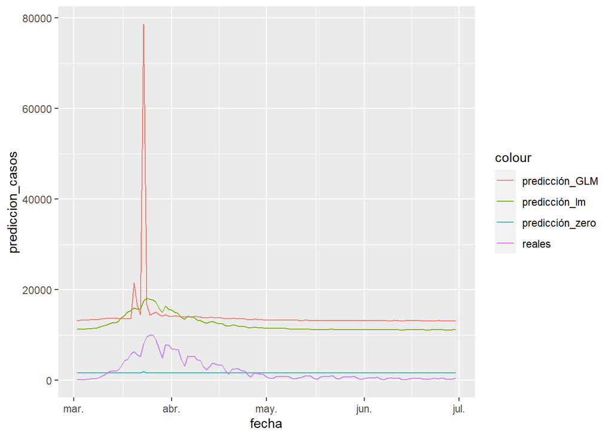

```r
names (casos_test)[6] = "hosp_10"

names (casos_test)[7] = "uci_12"

names (casos_test)[8] = "muertes_17"


casos_test$prediccion = (predict(fit.qpoisson, newdata=casos_test))^3

casos_test$prediccion_lm = (predict(fit.lm, newdata=casos_test))

casos_test$prediccion_zero = sqrt(sqrt(predict(fit.zip1, newdata=casos_test)))

prediccion_casos = casos_test %>%
    group_by(fecha) %>%
    summarize( prediccion_casos = sum(prediccion), prediccion_lm = sum(prediccion_lm), prediccion_zero = sum(prediccion_zero))


casos_comparacion = casos_comparacion %>%
                      group_by(fecha) %>%
                        summarize( casos_reales = sum(num_casos))

grafico_comparacion = merge(prediccion_casos, casos_comparacion, by = "fecha")


ggplot(grafico_comparacion, aes(fecha)) +
  geom_line(aes(y = prediccion_casos, colour = "predicción_GLM")) +
  geom_line(aes(y = prediccion_lm, colour = "predicción_lm"))+
  geom_line(aes(y = prediccion_zero, colour = "predicción_zero"))+
  geom_line(aes(y = casos_reales,  colour = "reales"))
```

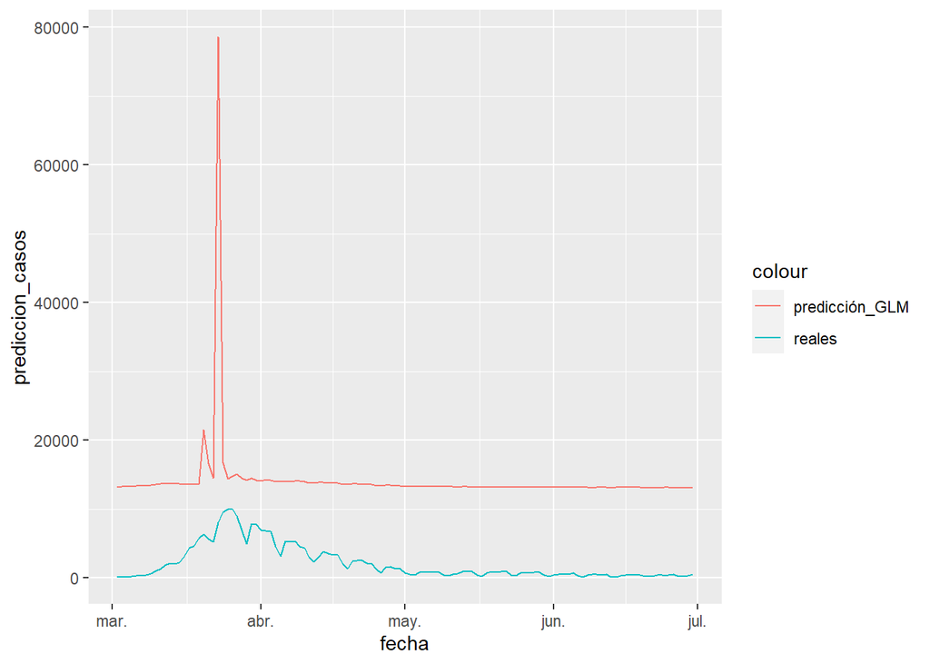

```r
ggplot(grafico_comparacion, aes(fecha)) +
  geom_line(aes(y = prediccion_casos, colour = "predicción_GLM")) +
  geom_line(aes(y = casos_reales,  colour = "reales"))
```

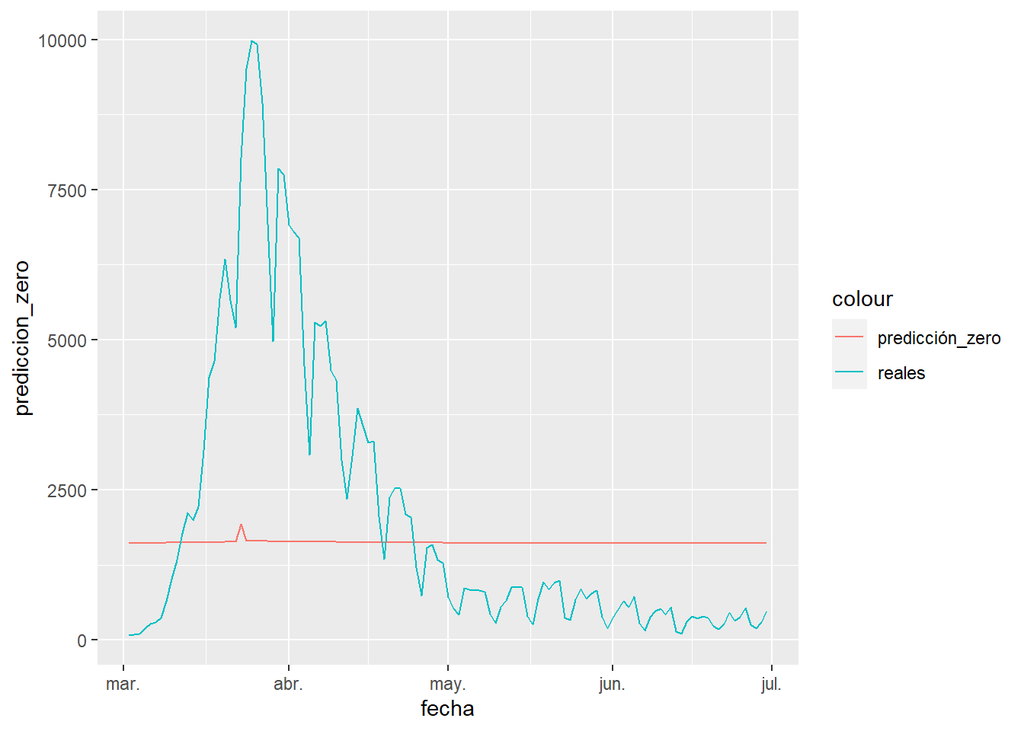

```r
ggplot(grafico_comparacion, aes(fecha)) +
  geom_line(aes(y = prediccion_zero, colour = "predicción_zero"))+
  geom_line(aes(y = casos_reales,  colour = "reales"))
```

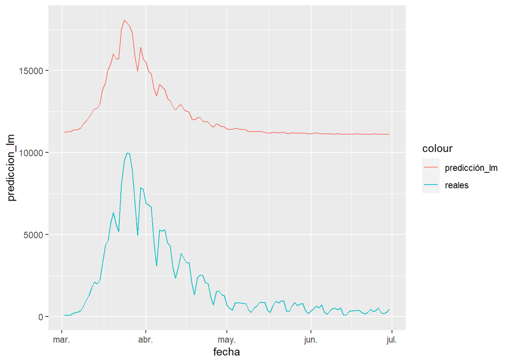

```r
ggplot(grafico_comparacion, aes(fecha)) +
  geom_line(aes(y = prediccion_lm, colour = "predicción_lm"))+
  geom_line(aes(y = casos_reales,  colour = "reales"))
```